# Alakazam

An interactive MATLAB workbench for EEG and event-related potential (ERP) analysis.

[figure not shown]

## Overview

Alakazam is a desktop application for EEG researchers: it loads a recording, lets the researcher apply a sequence of processing steps to it, and keeps the full processing history as an explorable tree rather than a one-off script result. It is built directly on the EEGLAB `EEG` data structure, so any result can be handed off to the wider EEGLAB/ERPLAB ecosystem, and it presents a "tree of datasets plus draggable transformations" workflow inspired by commercial analysers such as BrainVision Analyzer: each recording is a root node; every processing step (filtering, re-referencing, epoching, artefact removal, averaging, ...) produces a new child node.

The methodological approach follows established, reproducible ERP/EEG practice as described in Steven J. Luck's open textbook *Applied Event-Related Potential Data Analysis*, in Pütz, Span & Lorist (2025), a STAR Protocols paper walking through the same end-to-end design-record- preprocess-export workflow Alakazam is built around, and in the field's own current publication standards, Keil et al. (2014) (see References).

## Key features

- **EEGLAB-native data model.** Datasets are EEGLAB `EEG` structures, extended with a few Alakazam fields (`File`, `id`, `Call`, `params`, `DataType`, `DataFormat`) that record provenance and how each result was produced.
- **Two dataset trees with draggable, replayable transformations.** A "Data & Analyses" tree holds each recording as a root node with its analysis history as an explorable tree of child nodes; a separate "Grand Averages" tree holds combined results, which don't belong nested under any single subject. Applying a transformation to the selected dataset creates a new child node; dragging a processed branch onto another dataset re-applies the same chain of steps to it. A branch's right-click menu also offers **Apply to All Raw Files...**, which does the same to every other raw recording already in the workspace in one action, rather than dragging onto each one by hand. **Save Template...** exports that same branch as a portable `.alztemplate` file (a plain JSON list of steps, independent of this workspace's own cache files); **Apply Template...**, available on any dataset node, replays a saved template's steps onto it: the same recipe applied later, in another workspace, or after Alakazam has been restarted. (Not offered on a rendered report node in the Reports tree, see Statistical analysis: a report has none of the real dataset fields a transformation expects.)
- **Format support.** BrainVision (`.vhdr`, via the bva-io EEGLAB plugin), EEGLAB `.set`, ERPLAB erpsets (`.erp`, read directly as an already-averaged root dataset, no ERPLAB installation required, see `erpsetToAveraged`), and previously-saved Alakazam `.mat` sessions. Each raw file is cached to `.mat` on first read and only re-parsed if the raw file is newer than its cache. Any Averaged dataset's right-click menu offers **Export ERPset...**, the reverse conversion (`averagedToErpset`), to hand a result back to ERPLAB.
- **Fast visualisation of long recordings.** Continuous signals are drawn by a purpose-built renderer that decimates through a precomputed min/max pyramid, so scrolling and zooming stay smooth on multi-hour, multi-channel data while every spike and artefact remains visible (see Fast plotting).
- **Tabbed, tiled or undocked plot views.** Open datasets show one at a time as tabs, or all at once arranged in a grid or stacked column, for side-by-side comparison. Any one of them can also be given a window of its own (right-click its tab, then **Undock**), which is what a second monitor is for; its tab stays where it is and offers a **Dock** button, and closing the window puts the plot back. The same right-click menu closes a plot, or every plot but that one (**Close others**). Closing a plot discards nothing: the dataset and its tree node stay, so selecting the node again reopens it.
- **A transformation library covering the standard EEG/ERP pipeline**: filtering, re-referencing, channel/data selection, event-to-bin assignment with a small purpose-built language, baseline correction, trial averaging (including bin-difference/interaction contrasts), amplitude-threshold artefact marking, automated ICA- and GEDAI-based artefact removal, Fourier analysis, and scalp topography plots, including a rotatable 3D brain view with optional real source estimates, dSPM, eLORETA or sLORETA (see Transformations and 3D brain view); grand averaging across subjects is a separate mechanism with its own tree and dialog.
- **Design-aware statistical reporting.** Exporting ERP or Spectral Measure results also writes a companion Quarto/R report to a persistent Reports folder: one statistical test per window/frequency and measure type, chosen to fit the actual design: within-subjects (descriptive statistics, a paired test, or a linear mixed model for 3+ conditions), between-subjects or mixed once subjects are assigned to groups via **Grouping...** (a Welch *t*-test/ANOVA, or a linear mixed model with a condition x group interaction), or a one-sample test against zero for a difference bin. Every *t*-test-family comparison is also backed by a Bayes Factor and a bootstrapped effect-size confidence interval as a robustness check, with APA-styled tables, violin plots, and a closing forest plot of every effect size in the report. It is a real, human-editable Quarto document underneath, not a fixed template (see Statistical analysis).
- **Cluster-based permutation testing.** For when there is no pre-chosen channel/window to test: **Cluster Test...** (Export/Report tab) tests a contrast across the whole scalp and epoch at once (Maris & Oostenveld, 2007, via FieldTrip), correcting for multiple comparisons by exploiting spatiotemporal contiguity rather than a fixed per-point correction, with its own Quarto report showing where and when each cluster sits. **Source Cluster Test...** runs the same test over the cortical sheet instead of the scalp: each subject is inverted onto a template source space and the contrast is tested across every vertex and time point at once (see Cluster statistics).
- **Per-subject data quality.** **Data Quality Report** (Export/Report tab) reports how many trials each subject lost, how much per-trial noise was present, the standardized measurement error of each reported score (Luck et al., 2021), and whether the loss was even across conditions. Written as its own Quarto report alongside the others in the Reports tree (see Data quality).
- **The analysis as a runnable script.** **Export as Code** (Export/Report tab) writes the whole workspace out as a plain `.m` file: every recording's chain with the options actually used, identical subjects collapsed into one loop, settings hoisted to the top, and each step spelled as the underlying EEGLAB call (`pop_resample`, `pop_reref`, `pop_interp`, `pop_select`) wherever that is a faithful translation rather than a re-implementation (see Exporting the analysis as code).
- **Session workspaces.** Working directories and the processing tree are saved and reloaded as a workspace.

## Architecture

A single `uifigure` hosts the whole application: a control-strip ribbon along the top (Home/Tools/Grand Average tabs, discovering transformations automatically), three trees stacked on the left (Data & Analyses, Grand Averages, Reports -- selecting a node in one clears the other two), and the plots area on the right (tabbed or tiled, see above). The Alakazam tab's **Help** button opens this document as an in-app page, with screenshots and searchable with Ctrl+F. The page is generated from this file and is not kept in version control; if it has not been built, the button explains how and offers to open `README.MD` instead (see [`src/help/README.md`](https://github.com/markspan/Alakazam/blob/main/src/help/README.md)). Authored application code lives under `src/`; third-party toolkits and shared data-file resources stay at the repository root. See [`PROJECT_STRUCTURE.md`](https://github.com/markspan/Alakazam/blob/main/PROJECT_STRUCTURE.md) for the full map (including which pieces are build-time-only, like the Node.js tooling behind the tree widget) and [`dependencies.md`](https://github.com/markspan/Alakazam/blob/main/dependencies.md) for the external toolkits.

At startup the application resolves two roots from its own file location, so it does not depend on the current working directory:

- `RootDir` is the authored source tree (`src/`), holding the transformations.
- `RepoRoot` is the repository root, holding the vendored toolkits and resources.

> The ribbon and dataset trees are custom `uihtml` components, not MathWorks' own Toolstrip/tree widgets: an earlier version of Alakazam docked plot windows into a Java-Swing desktop shell, which stopped working once modern MATLAB releases moved `figure()` off Java Swing entirely. See [`migration.md`](https://github.com/markspan/Alakazam/blob/main/migration.md) for that history, if you're curious why the UI is built the way it is.

## Fast plotting

Continuous time-series are drawn by `SignalView`, backed by `MinMaxPyramid`. The pyramid precomputes, once, a stack of increasingly coarse levels that store the per-bucket minimum and maximum of the signal. A redraw then reads about one min/max column per screen pixel from the nearest level (or the raw samples when the visible window already fits the axis), so its cost is independent of the recording length. Because minima and maxima compose exactly, the decimated envelope never hides a spike or a brief artefact. The view provides pan, zoom, and y-axis magnify controls, mouse-wheel scrolling, channel stacking, and overlays for events and marked artefacts.

## Installation

Requirements: MATLAB (with `uifigure`/App Designer support: the UI is built entirely on that component family, not the classic figure/uicontrol one), the Signal Processing Toolbox (used by the `Filter` transform and the taper windows in `Fourier`) and the Statistics and Machine Learning Toolbox (used by EEGLAB and some of its plugins), plus the external toolkits listed in [`dependencies.md`](https://github.com/markspan/Alakazam/blob/main/dependencies.md), most importantly EEGLAB. Parallel Computing Toolbox is advised (not required) for the AutoGEDAI transformation: its GEDAI plugin dependency uses GPU acceleration when a GPU is actually detected, and falls back to CPU (via a small compatibility shim, `src/Compat/gpuDeviceCount.m`, on a machine without the toolbox at all) otherwise, so a machine without a GPU is just slower, not broken. [FieldTrip](https://www.fieldtriptoolbox.org/) is an optional, larger (~400 MB) dependency needed only for `Brain3D`'s Source-estimate mode (see 3D brain view); it downloads on first use of that mode, after an explicit consent prompt, not at startup.

Either clone the repository or download a packaged release from the [Releases page](https://github.com/markspan/Alakazam/releases). The release archive is the same source tree with the in-app help page already built, which a clone does not include (see [`src/help/README.md`](https://github.com/markspan/Alakazam/blob/main/src/help/README.md)).

```matlab
% From the repository root:
startAlakazam        % adds src/ to the path and opens the application
```

`startAlakazam` adds the authored source tree to the MATLAB path and constructs the app, which in turn adds the vendored toolkits from the repository root. On first run, EEGLAB is initialised if it is not already on the path (the global MATLAB path is left unchanged). At startup, `EEGLabEnvironment` also checks for the Signal Processing and Statistics and Machine Learning toolboxes and warns (without blocking startup) if either is missing.

## Getting started

This chapter is a guided first session. It assumes you know what an ERP is, what a filter does to one, and why anybody would want to average four hundred trials together; it assumes nothing at all about Alakazam. By the end of it you will have loaded a recording, filtered it, cut it into epochs, averaged it, done the same to everybody else in your sample, and produced a report. That is a whole study's analysis, in outline, and it takes about twenty minutes the first time.

If you would rather see the finished pipeline for a specific paradigm, the How-to walkthroughs give exact settings for P300, LRP and MMN designs, and a start-to-finish worked example on the ERP CORE N400 data. Come back here for the ideas those walkthroughs assume.

### First, give your recordings a room of their own

Before you launch anything, make a folder that contains your raw recordings **and nothing else**.

This is the single most common source of a confusing first hour, and it is worth one minute of tidying. Alakazam treats every file sitting directly in that folder as one recording, and gives each one a root node in its tree. Point it at a folder that also holds your stimulus scripts, a spreadsheet of demographics and three versions of a poster, and it will earnestly try to make sense of all of them. Point it at a clean folder of twenty `.set` files and you get twenty subjects, in order, and nothing to explain.

It reads `.set` (EEGLAB), `.vhdr` with its `.eeg` and `.vmrk` companions (BrainVision), `.erp` (an ERPLAB erpset, which arrives already averaged), and `.mat` (a session Alakazam saved earlier).

A workspace is really three folders, and it is worth knowing what each is for before you are asked to choose them:

| Folder | What lives there | Who writes to it |
| --- | --- | --- |
| **Raw** | your recordings, as they came off the amplifier | you, once |
| **Intermediate** | every result Alakazam computes, cached | Alakazam |
| **Exports** | CSV files, reports, scripts you asked for | Alakazam, when you ask |

The separation is deliberate, and it is the reason you can be relaxed about experimenting. Results never land in your raw folder. Every transformation writes into the Intermediate directory instead, in a subfolder named after the recording it came from, which is also what lets Alakazam rebuild your entire analysis tree next week without recomputing any of it.

A layout that works well:

```
MyExperiment/
    raw/          <- point Alakazam here
    cache/        <- Intermediate; safe to delete, costs only recomputation
    exports/      <- CSVs and reports end up here
```

### Launching, and the one question you will be asked

From the repository root:

```matlab
startAlakazam
```

On a machine that has never run Alakazam, there is no workspace yet. Rather than opening onto an empty tree and leaving you to wonder what you did wrong, a **Welcome** dialog appears and asks for your raw data folder. The field starts blank on purpose, and **OK** stays refused until you have actually chosen one, because a plausible-looking placeholder path is a worse start than an obvious empty box.

That dialog is not a special first-run wizard you will never see again. It is the same **Edit WorkSpace** control from the **Alakazam** tab, so when you move to a different study you already know where to change it.

### What you are looking at

The window has three regions, and they map onto three questions.

**Across the top, the ribbon: what can I do?** Four tabs.

- **Alakazam** holds the workspace itself: opening, saving and editing it, telling Alakazam about your experimental design, settings, the view mode, help.
- **Tools** holds the analysis steps, grouped the way an analysis actually proceeds: *Preprocessing*, *Artifact Rejection / Reduction*, *Segments*, *Frequency and Component Analysis*, and *Plots*. This tab is assembled from whatever transformations are installed, so it grows if you add one.
- **Grand Average** combines subjects.
- **Export/Report** turns results into files: CSVs, statistical reports, cluster tests, a data quality report, and your whole analysis as runnable code.

**Down the left, three trees: what do I have?** Not one tree, three, and the reason is worth a sentence. A **Data & Analyses** node belongs to exactly one recording. A **Grand Average** does not: it is made from many subjects at once, and nesting it under any one of them would be a small lie. A **Report** is not produced by one recording either, since a single report can summarise your whole sample. So each gets its own tree, and the divider between them can be dragged when one of them needs the room.

**On the right, the plots: what does it look like?** One tab per open recording. The **View** group offers **Tabs** (one at a time), **Grid** and **Stack** (all of them at once, for comparing). Right-click any plot tab to **Undock** it into a window of its own, which is what a second monitor is for, or to **Close others** when the strip has filled up.

### Opening a recording

Click a root node in the **Data & Analyses** tree. That is all: a single click loads and draws it. (Double-clicking reloads it, which is occasionally useful and never harmful.)

Continuous data opens in a scrolling view with the events marked on it. Before doing anything clever, it is worth spending a minute here just looking: at whether the events are where you expect, whether a channel is flat, whether there is a drift you will want to filter. Alakazam is quite happy to compute a beautiful grand average out of nonsense, and the cheapest moment to catch nonsense is now.

### Your first transformation

With the recording selected, go to **Tools**, find **1. Preprocessing**, and choose **Filter**. Set what you want and confirm.

Two things happen, and both matter more than the filter does.

First, a **new node appears underneath the recording** in the tree. Your original file has not been touched, and it will not be. What you are building is a history: the raw recording at the root, and each thing you did to it hanging below.

Second, the result is written to your Intermediate folder. That is not just housekeeping. It means that when you close Alakazam and open it again next Tuesday, that filtered dataset is still there, and clicking it is instant.

### The tree branches, and that is the whole point

Select the filtered node and run another transformation, and it lands beneath that one. Now select the **raw** node again and run something else. A second branch appears from the root.

This is the feature to understand early, because it changes how you work. You are never choosing between two preprocessing routes and losing one. Filter at 0.1 Hz on one branch and 0.5 Hz on the other, run both to an average, and put the two side by side with **Grid** view. The comparison costs you a few minutes, and either you learn that your effect is robust to the choice, which is reassuring, or you learn that it is not, which is considerably more important.

### Doing it again for everybody else

Twenty subjects, six steps each, is a hundred and twenty dialogs, and nobody should spend an afternoon that way. There are three ways out, in increasing order of ambition.

**Drag one node onto another recording.** Pick up a node, drop it on another subject's root, and Alakazam replays that step *and every step below it* onto the new recording, including branches where the analysis forked. One drag can reproduce an entire pipeline.

There is a nice special case here: drop one averaged dataset onto another matching averaged dataset and, instead of transforming anything, it overlays the two plots. It is the fastest way to put two conditions, or two subjects, on the same axes.

**Right-click a node and choose Apply to All Raw Files.** The same replay, to every recording in the workspace at once.

**Right-click and Save Template**, then **Apply Template** later. This writes the pipeline to a file, which is what you want when the next batch of subjects arrives in three months, or when a colleague asks what exactly you did.

### From continuous data to an ERP

The path from a recording to an ERP runs through **3. Segments**, where **DefineBins** turns event codes into conditions and cuts epochs around them, and then **Average** in the preprocessing group. Along the way you will generally want a **Baseline** correction and some artefact handling, either the threshold-based **ArtefactDetect** or one of the automatic routines.

The order matters, and it is a genuinely contested question in places rather than a matter of taste, so this chapter will not pretend otherwise: the How-to walkthroughs give a defensible order for each common paradigm, with the reasoning attached.

### Combining subjects, and getting numbers out

Once several subjects have an average, the **Grand Average** tab combines them, and the result appears in its own tree.

To get from pictures to numbers, run **ERP Measure** (in *4. Frequency and Component Analysis*) to say which windows, channels and measures you care about, then use the **Export/Report** tab. **ERP & Report** writes a CSV and, alongside it, a Quarto report that runs the statistical test appropriate to your design rather than a generic one, with the numbers written out in prose.

A rendered report gets a node in the **Reports** tree, and opens inside the application. It also carries a private copy of the CSV it was built from, so it stays reproducible even if you later overwrite the export. From the report view you can **Open in browser**, or **Open in Word** for a `.docx` next to it that you can paste into a manuscript.

### Saving, and what "saved" means here

Nothing about your workspace is written to disk automatically. **Save WorkSpace** on the **Alakazam** tab is the moment it happens, and it records your three directories, the most recent settings of every transformation you have run, and any group and subject assignments.

Your *results* are a separate matter, and they look after themselves: they are in the Intermediate cache as soon as they are computed. Deleting that cache costs you computation time and nothing else, which is precisely why **Clear WorkSpace** exists and why it is safe to use when an analysis has become a tangle.

### If something looks wrong

It probably is. A few places to look first.

- **Nothing appeared in the tree.** Either the raw folder is empty, or it holds formats Alakazam does not read. Check **Edit WorkSpace** first.
- **The numbers are odd.** Run the **Data Quality Report** from the **Export/Report** tab. It reports rejection rates per subject and per condition, flags subjects against conventional thresholds, and estimates how dependable your measurements actually are.
- **You want to know exactly what was done.** **Export as Code** writes your whole analysis as a runnable script, which is both a reproducibility artefact and an unusually honest answer to a reviewer.
- **You want the manual.** The **Help** button on the **Alakazam** tab opens this documentation inside the application.

### Where to go next

- Transformations for what each step actually does.
- How-to walkthroughs for complete recipes.
- Using your own data for the workspace, the experimental design editor and the display settings, in detail.
- Statistical analysis for what the reports contain and which test is chosen when.

## Transformations

A transformation is a small plugin in `src/Transformations/<Name>/`, consisting of an entry function `<Name>.m`, a JSON manifest `<Name>.json` (name, section, category, icon), and an icon. Manifests are discovered automatically and placed in the ribbon's Tools tab, grouped by the manifest's `Section` field.

A transformation receives an `EEG` structure and returns the transformed `EEG` together with an `options` struct describing what it did. When called interactively (from the ribbon) it prompts the user and remembers the chosen `options` (`TransformSettings`) for next time; when called with a previously captured `options` struct (dragging a branch onto another dataset, **Apply to All Raw Files...**, or replaying a saved template) it reproduces the operation without interaction: plain data, not a parsed or `eval`'d command string. Every transformation opens with the same `nargin`/`'Init'`-sentinel guard, [`TransTools.InitGuard`](https://github.com/markspan/Alakazam/blob/main/src/Transformations/+TransTools/InitGuard.m).

Every call is made through [`TransTools.invoke`](https://github.com/markspan/Alakazam/blob/main/src/Transformations/+TransTools/invoke.m), which validates the returned shape before it reaches the workspace tree: two outputs, an `EEG` that is empty (cancelled), a struct or a graphics handle, and an `options` that is a struct, empty or the `'Init'` sentinel. Previously four call sites each accepted whatever a transformation returned, so a plugin returning the wrong shape produced an error further down the pipeline rather than at its source. The seam's behaviour is specified in [`TransformContractTest.m`](https://github.com/markspan/Alakazam/blob/main/tests/TransformContractTest.m), which also asserts that no call site bypasses it.

```matlab
function [EEG, options] = SelectData(input, varargin)
% Example transformation (trimmed from the real SelectData.m).
% Returns the transformed EEG and an options struct the function understands.

    [opts, interactive] = TransTools.InitGuard(nargin, 'Alakazam:SelectData', varargin{:});
    if interactive
        % Interactive: prompt for options, remember them for next time.
        options = SelectDataDialog(input.chanlocs);
        if isempty(options)
            EEG = [];        % cancelled, no node, no compute
            options = [];    % BOTH outputs: the contract is two, always
            return;
        end
        TransformSettings.set('SelectData', options);
    else
        % Replay: reuse a previously captured options struct as-is.
        options = opts;
    end

    EEG = pop_select(input, buildSelectArgs(input, options){:});
end
```

The current library:

| Transformation | Does |
| --- | --- |
| `Filter` | FIR windowed-sinc, zero-phase high-pass / low-pass / notch filtering (EEGLAB's `firfilt`, Kaiser window). Each filter is set by just a frequency and a dB rating (stopband attenuation); the filter orde… |
| `Rectify` | Replaces a channel's signal with its magnitude (full-wave, `abs(x)`), half-wave (negatives zeroed), or its square -- the rectification step of a classic EMG-envelope pipeline. Records which mode ran, … |
| `DCDetrend` | Removes a slow drift from each channel by least-squares fitting a low-order polynomial (order 0 = mean, 1 = linear, 2 = slow curvature) and subtracting it -- per trial on epoched data, over the whole … |
| `ChannelEditor` | Edit channel labels, types and X/Y/Z coordinates in a table; look up positions from a chosen electrode template by label (Standard 10-5 by default, or any montage file dropped into [`src/Electrodes/`]… |
| `EventEditor` | Corrects the event table: rename or drop trigger codes, retain a subset, shift latencies in milliseconds, or edit a single event. Records the operations rather than the resulting table, so replaying i… |
| `Photodiode` | Measures display delay from a photodiode channel: pairs each light onset with the preceding trigger and reports the lag (median, IQR, range), which can then be corrected with `EventEditor`'s latency s… |
| `ReRef` | Re-references the data (wraps `pop_reref`). |
| `SelectData` | Channel and/or time-range selection (wraps `pop_select`). |
| `Interpolate` | Reconstructs bad channels from their neighbours (EEGLAB's `pop_interp`, spherical-spline and related methods), picked in an Alakazam channel-picker dialog. Bad channels are stored as labels, so a stor… |
| `Resample` | Changes the sampling rate of continuous data. |
| `DefineBins` | Assigns events to ERP bins with a small, purpose-built event-selection language: see [`bin_language.md`](https://github.com/markspan/Alakazam/blob/main/src/Transformations/DefineBins/bin_language.md) … |
| `DeriveChannels` | Adds channels computed from existing ones with `let <name> = <expression>` statements (e.g. `let LRP = C3 - C4`) -- the channel-arithmetic counterpart to `DefineBins`' bin arithmetic. Runs on continuo… |
| `Baseline` | Baseline-corrects epoched data. |
| `Average` | Averages one dataset's epoched trials into an ERP, including bin-difference/interaction contrast bins (see `bin_language.md` §11-12). |
| `ArtefactDetect` | Flags epochs exceeding an absolute amplitude threshold, or a step, peak-to-peak or sample-to-sample criterion. What happens to a flagged cell is chosen separately: reject the whole epoch, mark that ch… |
| `ManualReject` | The manual counterpart of `ArtefactDetect`: browse one trial at a time and click a channel to flag it faulty, with the same Whole-epoch / This-channel-only scope and, for a single channel, the choice … |
| `RemoveComponents` | Manually subtracts ICA components chosen by hand, from a sortable table showing each component's ICLabel-assigned class and confidence ("Eye 88%") alongside its full per-class probabilities and, where… |
| `AutoEyeICA` | Runs ICA, classifies components with ICLabel, and automatically removes eye components above a probability threshold. Shown in the ribbon as "AutoICA". |
| `AutoGEDAI` | Denoises with GEDAI (generalized eigenvalue decomposition against a leadfield reference; Ros et al., 2025). |
| `Fourier` | FFT-based frequency-domain analysis, with windowing and resolution options. Six output units: the four magnitude forms (`Volt`, `Power`, `VoltDens`, `PowerDens`), which take `abs()` per segment and so… |
| `Welch` | The same calibrated PSD for a **continuous** recording, which has no trials to average over: overlapping segments, each tapered, their periodograms averaged. Segment length sets the resolution/varianc… |
| `ScalpDistribution` | Scrubbable scalp-topography plot of an averaged ERP over a time window. |
| `Brain3D` | The same scrubbable ERP, projected onto a rotatable 3D brain surface, either as a scalp-topography projection (default) or a real source estimate: dSPM, eLORETA or sLORETA, as a magnitude or signed on… |
| `Measure` | Quantifies ERP components in named time windows: mean amplitude; peak amplitude + latency (absolute or local peak); area (signed / rectified / positive / negative, over the whole window or a peak-lock… |
| `CollapseHemispheres` | Contralateral and ipsilateral waveforms for an N2pc or LRP, collapsed across every matched lateral electrode pair at once: mark which bins are left-side and which are right-side, and it adds a Contra … |
| `TimeFrequency` | Wavelet time-frequency analysis: a per-bin, channel-stepped heatmap of event-related spectral power change relative to a pre-stimulus baseline (ERSP, dB). |
| `SourceEstimate` | Inverts every bin of an averaged dataset onto the template cortical sheet and stores the result on the node, so that a source cluster test reads it instead of computing it again. Reuse is granted only… |
| `SpectralMeasure` | Quantifies frequency-tagging / SSVEP / RIFT responses at named frequencies (a fundamental, its harmonics, or intermodulation terms): power, SNR, inter-trial phase-locking, and, against an optional pho… |
| `Covariance` | Channel-by-channel covariance or correlation matrix per bin, pooled over a bin's trials within a time window (BrainVision Analyzer's Covariance module, extended): optional Ledoit-Wolf shrinkage toward… |
| `CrossCorrelation` | Averaged cross-correlation of each channel to a reference channel: the Pearson correlation at each lag, computed per trial and averaged over a bin's trials, plus the peak correlation and the lag it oc… |
| `CoherenceMap` | Time-resolved coherence of every channel to a reference (e.g. a photodiode) as a per-channel time x frequency heatmap, via a Morlet wavelet or a fixed-window STFT: the RIFT-figure view (Dimigen et al.… |
| `CoherenceTopography` | Scalp head-map of every channel's coherence to a reference (e.g. a photodiode) per bin, at the reference's auto-detected tagging frequency. Shown in the ribbon as "CohTopo". |

`TimeFrequency`'s own grid view, one event-related spectral perturbation (ERSP) heatmap per bin, channel-stepped and baseline-corrected:

[figure not shown]

Grand averaging (combining several subjects' `Average` results into one) is a separate mechanism, not a transformation plugin: it has its own ribbon tab and dialog (`GrandAverage.m`/`GrandAverageDialog.m`) and lands in the "Grand Averages" tree rather than nested under any one subject's branch (see Key features).

**3D brain view** (click to expand)**

## 3D brain view

`Brain3D` opens the same scrubbable, per-bin averaged ERP as `ScalpDistribution`, but drawn on a rotatable 3D brain (click-and-drag to orbit) instead of a flat 2D topoplot, with a **Projection** dropdown choosing how the data is drawn.

`ScalpDistribution`'s own flat, scrubbable topography, one head per bin:

[figure not shown]

The same underlying projection, on `Brain3D`'s rotatable 3D surface:

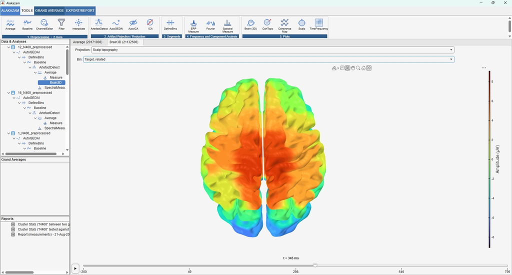

- **Scalp topography** (the default) is the same spherical-spline interpolation `ScalpDistribution`'s flat topoplot uses, projected onto a brain-shaped surface (a BrainNet Viewer ICBM152 mesh) purely for legibility. It is **not source-localized**: the colour scale is the measured scalp voltage itself (µV, signed, symmetric about zero), exactly as in the flat 2D plot.
- **Source estimate (dSPM / eLORETA / sLORETA)** are real inverse computations, all three using [FieldTrip](https://www.fieldtriptoolbox.org/)'s template BEM head model, template 10-5 electrode positions, and a template cortical-sheet source model, drawn directly on that cortical surface. Selecting one the first time prompts to download FieldTrip (about 400 MB, one time, opt-in, see [`dependencies.md`](https://github.com/markspan/Alakazam/blob/main/dependencies.md)); switching into it, or onto a bin not yet computed, takes a moment longer than scalp mode while the leadfield/inverse is built (cached afterwards per channel set/bin/method). The leadfield is a property of the head and the electrodes, not of the method, so switching between the three re-solves without rebuilding it.

  | Method | What it is |
  | --- | --- |
  | **dSPM** | Tikhonov-regularized minimum norm, noise-normalized (Dale et al., 2000). |
  | **eLORETA** | Exact low-resolution tomography (Pascual-Marqui, 2007): zero localization error for a single source, but an amplitude rather than a normalized statistic. |
  | **sLORETA** | Standardized low-resolution tomography (Pascual-Marqui, 2002), standardized by its own resolution matrix rather than by projected noise. |

  **The three scales are not comparable to each other, and none is in µV.** Each result carries its own colorbar label from [`InverseSolution`](https://github.com/markspan/Alakazam/blob/main/src/Transformations/+TransTools/InverseSolution.m) rather than a label fixed in the view, so a map cannot be drawn under another method's scale. dSPM normalization corrects the raw minimum norm's bias toward superficial sources and yields a statistic, approximately the number of noise standard deviations above baseline, which is comparable *across* source locations where raw dipole-moment magnitude is not. It remains a statistic rather than a physical amplitude, and none of these values should be compared with the scalp mode's µV scale.

  The three inverse methods are computed by FieldTrip, which is asked for the spatial filter only. Projection through the filter, the per-method scaling and the collapse of free-orientation moments are performed in Alakazam along a single shared path, which keeps the dSPM normalization explicit rather than dependent on the convention a given FieldTrip function uses for its power output. An independent implementation ([`ComputeSourceEstimate`](https://github.com/markspan/Alakazam/blob/main/src/Transformations/+TransTools/ComputeSourceEstimate.m)) is retained as a reference: the two agree to floating-point equality on the test fixture, so routing the existing dSPM path through FieldTrip does not change results (see [`SourceInverseTest.m`](https://github.com/markspan/Alakazam/blob/main/tests/SourceInverseTest.m)).

  **Signed (cortical normal)** is a further choice, available in any of the three inverse modes. A free-orientation inverse yields three dipole components per vertex; by default these are reduced to their L2 norm, which is non-negative and therefore cannot represent the polarity of a component. Ticking the box projects each vertex onto its cortical normal instead, retaining the sign, and draws the result on a diverging scale symmetric about zero. Pyramidal cells are oriented perpendicular to the cortical sheet, so the normal is the conventional orientation constraint for EEG. The default remains the magnitude, which is the usual source-map display.

  One further simplification: the assumed noise covariance behind both the regularization and the dSPM normalization itself is a scaled identity, not an independently estimated one, since Alakazam's pipeline runs on already-averaged ERPs, with no single-trial baseline available at this stage to estimate a real noise covariance from (see [`ComputeSourceEstimate.m`](https://github.com/markspan/Alakazam/blob/main/src/Transformations/+TransTools/ComputeSourceEstimate.m) for the full derivation).

  **This is template-based, not a per-subject localization.** No per-subject MRI or digitised electrode positions are used (same "10-5 template by channel label" approach the rest of Alakazam uses for scalp topography): a real inverse computation, more physiologically grounded than the scalp-topography projection, but still an approximation.

## Measurement export

`Measure` turns a window on a waveform into a number: define one or more named windows (a table editor, add/remove rows) and it computes each one's value per bin and channel, stored on the result as `EEG.measurements`. The dialog's own **Save.../Load...** (matching `DefineBins`' own Save/Load pair) saves the table's current rows to a portable `.alm` JSON file, so a window set can be reused across dialogs, workspaces, or shared with a colleague, independent of any one dataset's Recalculate history. Because it is an ordinary transformation, a whole `raw -> filter -> epoch -> baseline -> artefact-reject -> average -> measure` pipeline can be defined once and replayed across a study with Apply to All Raw Files or a saved template (see Key features), no need to re-run Measure by hand on every subject.

The **Export/Report** ribbon tab's **ERP & Report** button walks the whole workspace (every subject branch and every Grand Average, in either tree) for a Measure result and writes one long-format, R-compatible CSV: one row per dataset x window x bin x channel x measure type (`mean_amplitude`, `peak_amplitude`, `peak_latency`, `area_signed` / `area_rectified` / `area_positive` / `area_negative`, `fractional_peak_latency`, `fractional_area_latency`; a measure that yields several values, such as Peak or a peak-locked Area, contributes one row per value, so the CSV's own `value` column stays uniformly numeric), plus a `group` column (see Groups, blank unless subjects have been assigned one). The same bulk-export-everything idea as **Export Grand Averages...** (see [`exportGrandAveragesCSV.m`](https://github.com/markspan/Alakazam/blob/main/src/Reports/exportGrandAveragesCSV.m)), implemented in [`exportMeasurementsCSV.m`](https://github.com/markspan/Alakazam/blob/main/src/Reports/exportMeasurementsCSV.m). The full window/ measure reference, with worked examples, is [`measure.md`](https://github.com/markspan/Alakazam/blob/main/src/Transformations/Measure/measure.md). The same button also renders a companion statistical report, see Statistical analysis.

Two companion files are written into the same Reports folder when the material for them exists, both named after the same stem so the set stays together if the folder is moved:

- **`..._grandaverages.csv`**, the waveforms the measurements were read from, which is what lets the report draw the grand averages and the difference wave with each measurement window shaded on them ([`exportGrandAveragesCSV.m`](https://github.com/markspan/Alakazam/blob/main/src/Reports/exportGrandAveragesCSV.m)).
- **`..._trials.csv`**, one row per dataset x window x **trial** x channel x measure type, written whenever some node in the workspace carries per-trial measurements. That happens when `Measure` is run on the **epoched** node rather than on the Average: the same window definitions then yield one value per trial instead of one per bin. It is what the report's single-trial models are fitted to ([`exportTrialMeasurementsCSV.m`](https://github.com/markspan/Alakazam/blob/main/src/Reports/exportTrialMeasurementsCSV.m)).

Both are best effort: a workspace with no grand averages, or no epoched Measure node, simply gets a report without those sections, and a file that fails to write costs its figures rather than the export.

**Statistical analysis** (click to expand)**

## Statistical analysis

Exporting Measure or Spectral Measure results (the **Export/Report** ribbon tab's **ERP & Report** and **Spectral & Report** buttons, see Measurement export and Frequency analysis) writes a companion [Quarto](https://quarto.org/) report, alongside a private copy of its own CSV so the report stays reproducible even if the original export is later overwritten, both saved into a dedicated **Reports** folder inside the workspace's Exports directory. Unlike an ordinary export, a rendered report is not a one-off file to go hunting for: it gets its own node in a third workspace tree (**Reports**, alongside **Data & Analyses** and **Grand Averages**), which survives closing and reopening the workspace, and an **Open in browser** button (the embedded viewer runs a current browser engine and renders the report's own styling, but it is a narrow pane, so wide tables and a sticky table of contents have more room in a window, and printing and saving belong to a browser anyway). Beside it, **Open in Word** writes a `.docx` next to the report and opens it, for pasting results into a manuscript: it converts the rendered HTML with pandoc rather than re-rendering the document, which takes about a second, needs no R, and works on reports rendered before the button existed. Note that asking Quarto itself for Word output (`quarto render <name>.qmd --to docx`) does *not* work on these reports: the results tables come out as runs of text rather than tables, because they are emitted as raw HTML from inside `results: asis` chunks. Rendering (`quarto render <name>.qmd`, self-contained HTML) produces a short, APA-styled results report, not just a table: tables in three-line APA format, violin plots showing the actual distribution rather than just a bar and an error bar, and narrative prose ("The model revealed a significant effect of bin, *F*(2, 18) = 6.4, *p* = .008, ...").

A rendered report, opened in a real browser: the sticky table of contents, the LMM fixed-effect and Holm-corrected pairwise-comparison tables, the Friedman robustness check, and a per-subject violin plot:

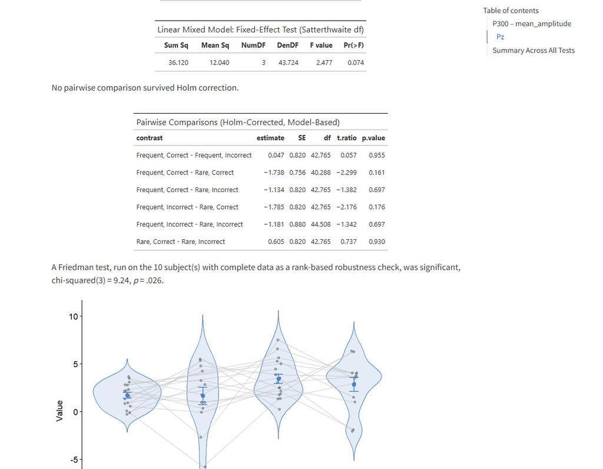

### What gets tested, and what question it answers

The report is design-aware: it is built at generation time in MATLAB, where the actual bin structure (`EEG.bindesc`) and, once assigned, each subject's between-subjects group (see Groups below) are both still known, neither is recoverable from the flat CSV alone, so it can choose the statistical test each window/frequency x measure-type combination actually calls for, rather than one generic script re-discovering the design at runtime. One section per window (ERP) or named frequency (Spectral) x measure type:

| Design | Test(s) | Question it answers |
| --- | --- | --- |
| One ordinary bin | Descriptive statistics only | What is this measure's mean/SD? (no comparison is possible with one condition) |
| Any number of ordinary bins, a **circular** measure type (phase, phaselag) | Circular descriptive statistics: mean angle with a bootstrap CI, and resultant length *R̄*; no test | An angle wrapping at ±π cannot go into a *t*-test, a mixed model, or even an ordinary mean: the arithmetic mean of 179° and −179° is 0°, the point opposite where the data are |
| Two ordinary bins | Paired *t*-test + Cohen's *dz* (bootstrapped CI) + Bayes Factor, Wilcoxon signed-rank robustness check, Shapiro-Wilk normality note | Does this measure differ between the two conditions, within subjects? |
| Three or more ordinary bins | Linear mixed model (random intercept + slope for bin **per person**, falling back to intercept-only if that fails to converge) + partial eta-squared with CI + Holm-corrected model-based pairwise contr… | Does this measure differ across conditions, within subjects, using every subject's available bins even if one is missing for them? Which specific pairs of conditions differ? |
| One ordinary bin, **2 groups** assigned | Independent-samples Welch *t*-test + Cohen's *d* (bootstrapped CI) + Bayes Factor, Mann-Whitney *U* robustness check | Does this measure differ **between** the two groups (e.g. patients vs. controls)? |
| One ordinary bin, **3+ groups** assigned | Welch's ANOVA + Games-Howell pairwise comparisons | Does this measure differ between the groups? Which pairs of groups differ? |
| Two or more ordinary bins, **groups** assigned | Linear mixed model with a condition x group interaction (same random-effects/fallback logic as above) + partial eta-squared with CI + Holm-corrected within-group and between-group pairwise comparisons… | Does the **condition effect itself differ between groups** (the interaction, usually the actually-interesting question in a mixed design)? Plus: is there a main effect of condition, or of group, on it… |
| Two or more ordinary bins, **sessions** assigned | Linear mixed model with a condition x session interaction (same random-effects/fallback logic) + partial eta-squared with CI + Holm-corrected contrasts, run only if the interaction or the main effect … | Does the condition effect **change between sessions** (pre vs. post, day 1 vs. day 2)? |
| Two or more ordinary bins, **sessions and groups** assigned | Linear mixed model with every main effect and every two-way interaction, `(bin + session + group)^2`; the three-way interaction is deliberately omitted | Does the condition effect differ between sessions, and between groups, without asking for a three-way term the subject count rarely supports? |
| Combination/difference bin (amplitude, area, power, SNR, ITC, coherence, ...) | One-sample *t*-test (+ Wilcoxon) against zero, Cohen's *dz* (bootstrapped CI) + Bayes Factor | Is this effect (a priming effect, an oddball effect, ...) actually present? |
| Combination/difference bin, a **latency** (peak, fractional peak, fractional area) | Descriptive statistics only | (latency has no natural zero to test *against*: see below) |
| Combination/difference bin, a **circular** quantity (phase, phaselag) | Circular descriptive statistics only | (an angle wrapping at ±π is not valid for an ordinary linear test: see below) |
| Combination/difference bin (amplitude/area/power/...), **groups** assigned | One-sample test **within each group** + independent-samples test of the difference score **between groups**, each with Cohen's *d*/*dz* (bootstrapped CI) + Bayes Factor | Does the effect exist within each group? Does the effect's **size** differ between groups (e.g. "is the priming effect different in patients than in controls")? |
| Combination/difference bin, a **latency**, **groups** assigned | Independent-samples test **between groups** only (still no vs.-zero test) | Does the effect's *timing* differ between groups? |
| Combination/difference bin, **circular**, **groups** assigned | Descriptive statistics only, per group | (still no linear test is valid, one-sample or between-groups) |

The 3+-bin, mixed-design and session rows deliberately use a **linear mixed model** (`lme4`/`lmerTest`), not a repeated-measures or split-plot ANOVA: the LMM's whole point here is that a subject missing one bin still contributes their other bins to the fit, instead of being listwise-dropped from the entire channel the way a classic RM-ANOVA would drop them. A maximal model (random intercept **and** slope per subject) is tried first and falls back to a random-intercept-only model, narrated in the report, if the maximal one fails to converge to a non-singular fit, typically too few subjects/observations for that many random parameters. The 3+-group between-subjects row uses **Welch's ANOVA + Games-Howell**, not classic ANOVA + Tukey, for the same reason the paired/between tests already default to Welch over Student's *t*: it does not assume equal variances between groups, which real between-subjects EEG samples rarely satisfy exactly.

A combination bin's own test is always kept separate from the omnibus test over the ordinary bins above it, even when both are in the same report: its scores are a linear combination of the other bins' scores, not an independent condition, so folding it into the same model would be statistically invalid. A **latency** has no natural "zero" to test *against* (zero would mean "no difference" for an amplitude; it means nothing of the kind for a point in time), which is why it drops the one-sample test but keeps the between-groups one: a latency is still an ordinary linear quantity, groups can still be validly compared on it. A **circular** quantity (phase/phaselag, an angle wrapping at ±π radians) drops *every* test, one-sample and between-groups alike, since neither is valid for circular data without dedicated circular-statistics machinery this generator does not have.

Every *t*-test-family comparison in the table above (paired, one-sample-vs- zero, independent 2-group, and the within-/between-group combo-bin variants) is also backed by a Bayes Factor (`BayesFactor::ttestBF`) as an added robustness check alongside its Wilcoxon/Mann-Whitney/Friedman equivalent, and every Cohen's *d*/*dz* effect size carries a bootstrapped (BCa, 200 resamples) confidence interval, not just a point estimate. The omnibus LMM tests report partial eta-squared with a genuine confidence interval (`effectsize::F_to_eta2`, via the model's F-statistic) instead of marginal R^2 for exactly this reason: R^2 alone has no CI to plot.

Every section's own key test result also feeds one final cross-report summary table, Benjamini-Hochberg (BH/FDR) corrected across every channel, window/frequency and measure-type test the whole export produced, not just within one section's own pairwise comparisons, plus a closing **forest plot** (effect size + CI, faceted by effect-size type since Cohen's *d* and partial eta-squared are different scales) so every effect in the report can be compared at a glance, not just read off one table at a time. Each channel's own analysis runs inside its own error boundary, so an edge case on one channel (too few usable subjects for a normality check, missing data for that channel only, ...) is reported for that one channel alone and does not stop the rest of the report from rendering.

### Groups: setting up a between-subjects or mixed design

Every design starts out within-subjects: every bin/condition is assumed to be measured on every subject, matched by `dataset` in the CSV. To ask a between-subjects question instead ("do patients and controls differ", see Kappenman & Luck, 2016, on the extra methodological care this kind of clinical-population comparison needs, in References), assign each subject to a group first, via **Grouping...** (the Home ribbon tab's own **Design** group), the "Edit Subjects" dialog: one row per subject, every root node in the Data & Analyses tree, with a free-text **Group** label; leave it blank for "no group". A subject left blank is excluded from every group-based test (with a count and a reason in the rendered report), but still counted normally in a report that turns out to have no groups active at all. Like the workspace's own directories, group assignment lives only in this session until saved with **Save WorkSpace**.

Once at least two distinct group labels are actually in use, both exporters add a `group` column to their CSV, and `generateQuartoReport` switches every relevant section from its within-subjects test to the matching between-subjects or mixed one in the table above, automatically, from the data, with nothing else to configure. A workspace where nobody has been assigned a group (or everybody shares the same one label) renders exactly as it always has.

The same dialog has three more columns. **Person ID** and **Session** are for linking multiple raw-file recordings of the same person (e.g. "...day1", "...day2") together: give them the same Person ID and an optional Session label ("Day 1", "Pre", "Post", ...) to record that they are repeated measurements of one person, not unrelated subjects. Person ID is pre-filled per raw file with whatever substring varies once every part of the filename common to *all* raw files in the workspace is stripped out (an experiment name shared by every recording cannot help tell subjects apart, so it is not worth leaving in the suggestion). Both columns reach the exported CSV (`person_id`/`session`) and both are used by the statistical report.

`person_id` is what the report groups its random effect by, so a person recorded twice counts as one subject rather than two. Where nobody has set a Person ID it is the recording's own name, which is why single-session studies are unaffected by this.

`session` becomes a within-subjects factor in its own right, crossed with bin, whenever the recordings support one: two or more session labels, at least two people measured under more than one of them, and no empty cell in the crossing. There is no switch to turn this on. If the recordings do not support it, the report fits the simpler model and prints why, rather than fitting an interaction it cannot estimate. See the design table for the models this produces, and **Show Design** (Alakazam tab, Design group) for what Alakazam believes your design to be before you run anything.

**In study** is the third. It is ticked by default, and unticking it takes that recording out of every report, statistic and grand average, with the count and the names of what was excluded printed where the design is shown. It replaces an older implicit rule, where a recording with no group assigned was silently dropped from grouped tests: the decision is now the analyst's, and visible, rather than a side effect of leaving a field blank.

### The signal behind the numbers

Every test above reports a statistic **on a measurement**: a mean amplitude over 300-500 ms at Cz, or power at 10 Hz. The report also draws the signal that measurement was read from, because a window over the wrong peak, a polarity flip, a baseline that never got applied, or a component that simply is not there all produce numbers that test perfectly well and mean nothing, and all four are obvious at a glance on the wave.

For an ERP export it draws the **grand-average waveforms** per condition with the measurement window shaded, and, for a two-condition design, the **difference wave**. The shaded band is read from `window_start_ms` and `window_stop_ms` in the export itself, so it cannot drift out of step with the interval that was actually measured. The condition ribbons are each condition's own standard error: they describe the conditions and not the difference between them, and whether they overlap is not evidence about a within-subject effect, which is exactly why the difference is drawn separately. No paired standard error is drawn on the difference wave, because that needs the covariance between the two conditions and a grand-average export carries only each condition's own error; a band appears only where there are several grand averages to take one across, and is labelled as the spread between those.

For a Spectral export it draws the **evoked amplitude spectra** with the tested frequencies marked, taken from the export so a mark cannot drift from the value reported beside it. That catches the failures particular to frequency tagging: a tag that is simply absent still yields a power value and an SNR near 1, a response one bin away from where it was measured looks like a weak effect rather than a misplaced measurement, and an SNR computed against a neighbour band that is itself contaminated reads as an ordinary number.

Both need their companion export to have been written (`..._grandaverages.csv`, `..._spectra.csv`), which the measurement and spectral exports now do automatically; without it the section says so and the rest of the report is unaffected.

### Seeing the effect, not just the conditions

Every plot of conditions answers "what did each condition look like"; none of them answers "how big is the difference, and how well is it pinned down", which is the quantity every test in the report is actually about. So a paired comparison and a combination bin each get a second panel: the effect itself, as a bootstrap distribution of the mean difference with its 95% interval, on an axis whose zero is always drawn. Where zero sits relative to that interval is the figure's whole point, and an axis that omitted zero would make any effect look decisive.

The condition plots are **rainclouds** rather than bare violins. The density and the individual observations used to sit on top of each other, so neither could be read; nudging the density and a narrow box aside leaves the points clear, and bimodality or a single subject carrying an effect becomes visible rather than smoothed into a shape.

For a circular measure there is no test, but there is now an interval: the mean angle carries a bootstrap CI over subjects. That matters more than it would for a linear measure, because an interval spanning much of the circle is how near-uniform angles announce themselves, and it is the signal that the mean direction should not be quoted at all. The resultant length *R̄* says how concentrated the angles are; the interval says how well the direction is pinned down, and the same *R̄* at five subjects and forty supports very different claims.

### Single-trial models

Where a per-trial export is present, the report also fits the measure to the **individual trials** rather than to per-subject averages (`value ~ bin + trial_c + (1 + bin | person_id)`). Averaging first discards everything inside a subject, and weights a subject with 12 usable trials exactly like one with 90 though the first estimate is far noisier. Fitting the trials lets the model see that, and makes the within-subject variance estimable rather than averaged away. This is the current standard for ERP inference (Frömer et al., 2018; Volpert-Esmond et al., 2021).

Trial order enters as a covariate, centred within person: single-trial amplitude drifts across a session with fatigue and habituation, and that drift is confounded with condition whenever the design is not perfectly counterbalanced in order. Controlling for it is one of the main reasons to model trials at all.

The random structure starts maximal (Barr et al., 2013) and is reduced only when it will not stand up, dropping the **correlation** between random terms first and the slope only after that (Bates et al., 2015); the report names which structure was actually fitted, since singular fits are common at ERP trial counts and a reader cannot otherwise tell.

To produce the per-trial export, run **Measure on the epoched node** rather than on the Average: the same window definitions then yield one value per trial instead of one per bin, stored as `EEG.trialMeasurements`. The measurement export writes them to `..._trials.csv` beside the report.

### Primary and secondary tests

Benjamini-Hochberg assumes a family of distinct tests, and the rows this report produces are not all distinct. A two-condition design yields an omnibus on the conditions, a one-sample test of the difference bin that re-expresses the same contrast, and (where trials are exported) a single-trial model that re-analyses the same data: three rows, one hypothesis.

So the planned condition comparisons form the **primary family** and are corrected together. Difference-bin tests, between-group follow-ups on those, and single-trial re-analyses are reported as **secondary**, with their uncorrected *p* and no adjusted value at all. Correcting across them would enlarge the family with rows carrying no independent information, which makes the adjustment look stricter while protecting against nothing.

Each result is stated **estimate first**: which condition was larger, by how much, and with what confidence interval, before any test decision. The interval says which effect sizes are compatible with the data, where a *p*-value says only whether zero is among them. A short "How to read this report" section at the top of every document states these conventions, including a plain note that where windows and channels were chosen after seeing the data, the *p*-values are optimistic in a way no correction repairs.

### It's just R and Quarto underneath

The generated `.qmd` is an ordinary, human-editable Quarto document, not a locked report format: every test in the table above is a plain `tidyverse`/`rstatix`/`lme4`/`emmeans`/`BayesFactor` call (see the package list below) over a `dat` tibble read straight from the CSV copy sitting next to it. Open the `.qmd` itself (in the Reports folder, next to its `.html` and its own CSV copy) in RStudio, VS Code, or any text editor, and add, change, or remove anything: a fully Bayesian alternative (`brms`), a random-effects structure the built-in LMM does not try, a custom plot, a subset of channels or subjects, extra covariates joined in from elsewhere: exactly as in any other Quarto/R document, then render it again (`quarto render <name>.qmd`, or the "Render" button in RStudio/VS Code). The auto-generated report is a statistically-considered starting point for this specific export's own design, tailored to it rather than generic, but it is not the last word on it: if a test exists in R, it can go in this report.

If Quarto or R (with the `tidyverse`, `rstatix`, `ggpubr`, `gt`, `BayesFactor`, `lme4`, `lmerTest`, `emmeans`, `performance` and `effectsize` packages, installed automatically by the report's own setup step on first render) are not found on this machine, the `.qmd` and its CSV are still written and the export still succeeds; render it manually once they are available (the export's completion dialog gives the exact command).

Generated by [`generateQuartoReport.m`](https://github.com/markspan/Alakazam/blob/main/src/Reports/generateQuartoReport.m).

**Cluster statistics** (whole-scalp, whole-epoch testing: click to expand)**

## Cluster statistics (whole-scalp, whole-epoch testing)

The Statistical analysis report above always tests one pre-chosen channel and window at a time, exactly right when a literature-grounded hypothesis already says where and when an effect should appear (an N400 at Cz, 300-500 ms). **Cluster Test...** (the **Export/Report** tab's own **Cluster Statistics** group) answers a different question: does an effect exist *anywhere* across the whole scalp and the whole epoch, without committing to a channel or window in advance, the case for an exploratory analysis, a new paradigm, or replicating someone else's effect without knowing if it lands at the same site/latency in your own data.

Testing every channel x time point individually would need thousands of individual comparisons, either hopelessly conservative to correct for properly or badly underpowered: the mass-univariate multiple-comparisons problem Groppe, Urbach & Kutas (2011) survey across the several corrections in common use. Cluster-based permutation testing (Maris & Oostenveld, 2007) sidesteps that by exploiting a real property of EEG: a genuine effect is never one isolated point, it is smeared across neighbouring electrodes and adjacent samples. It groups contiguous above-threshold points into spatiotemporal clusters, sums the test statistic within each, and compares that against a null distribution built by repeatedly shuffling condition/group labels and re-clustering: one family-wise-error-corrected p-value per cluster, not one per point.

This wraps [FieldTrip](https://www.fieldtriptoolbox.org/)'s own `ft_timelockstatistics`/`ft_prepare_neighbours`/`ft_prepare_layout` (the same pinned dependency `Brain3D`'s Source-estimate mode already uses, downloaded once with consent, see 3D brain view) as the actual statistical engine, rather than reimplementing the permutation machinery: EEGLAB itself has no native equivalent (its own `statcondfieldtrip.m` already delegates to FieldTrip for exactly this).

### Setting up a test

**Cluster Test...** offers three contrasts, gated by the same subject list Grand Average draws from (every Averaged ERP dataset in the workspace) and the same `Grouping...` assignment the Statistical analysis report already reads:

- **One bin against zero, within subjects**: typically a `DefineBins` combination/difference bin (e.g. an "N400" = unrelated - related contrast): is this effect reliably present anywhere?
- **Two bins, within subjects (paired)**: does condition A differ from condition B anywhere, without picking a channel/window first?
- **One bin, between two groups**: only shown once at least two distinct groups are assigned; does this measure differ between the groups, anywhere?

Three or more bins/groups at once (an omnibus or interaction cluster test) is not yet supported, as it needs a different design shape, left for later (TODO)

The options below the contrast picker come with sensible defaults, each with its own plain-language tooltip: **Correction method** defaults to **TFCE** (Threshold-Free Cluster Enhancement; Smith & Nichols, 2009), which avoids having to pick an arbitrary cluster-forming threshold at all: the classic fixed-threshold recipe is offered too, for anyone who wants the textbook Maris & Oostenveld method specifically. **Permutations** defaults to 1000; if that count is already close to the design's own exhaustive limit (every subject contributes exactly one real/comparison pair, so the exhaustive count is a bounded 2^subjects sign-flips), it is automatically upgraded to FieldTrip's own exhaustive `'all'` rather than a merely-close-to-it random sample, the same point FieldTrip's own console would otherwise warn about.

### The report

Running the test shows an immediate on-screen summary (every cluster found, significant or not: a near-miss is still worth seeing), then writes and renders a companion Quarto report the same way Statistical analysis does: narrative prose explaining the test that ran, a summary table of every cluster, an overview heatmap of the test statistic across the whole channel x time grid with cluster boundaries outlined, and, for the strongest few clusters, a topographic plot (**where** the cluster sits on the scalp) alongside a time-course plot (**when** it occurs, the cluster's own window shaded against each condition's grand-average waveform).

It also draws the **permutation null distribution itself**, per tail, with the observed cluster masses marked on it. A cluster-based permutation test compares one number, a cluster's mass (the test statistic summed over the points it contains), against the distribution of that same number under relabelling; every other figure shows where and when an effect was, and this one shows the comparison the *p*-value came from. It answers at a glance how far into the tail the observed cluster sits, whether the null is tight or broad, and whether the largest cluster is exceptional or merely the largest of several similar ones, which a single *p*-value cannot address. The distribution is exported too, as **`..._nulldist.csv`** (`tail,kind,value`) alongside the report's other CSVs ([`exportClusterStatsCSVs.m`](https://github.com/markspan/Alakazam/blob/main/src/Reports/exportClusterStatsCSVs.m)). Under TFCE there is no such figure: it scores each point by the support it gathers across thresholds rather than forming discrete clusters, so no cluster mass exists to plot. The section says so rather than drawing an empty panel, and the CSV is written with its header alone, so nothing downstream has to distinguish a missing file from an empty one.

It lands in the **Reports** tree exactly like the ERP/Spectral reports, labelled `Cluster Stats (<contrast>) - <timestamp>`.

Needs channel positions the standard 10-5 system recognises (auto-filled from a bundled template, the same mechanism `AutoEyeICA` already uses: rename or exclude any channel it does not recognise first) and, on first use, FieldTrip itself (a ~400 MB download, consent-gated, shared with `Brain3D`'s own Source-estimate mode).

Generated by [`ClusterStats.m`](https://github.com/markspan/Alakazam/blob/main/src/ClusterStats.m) and [`generateClusterStatsReport.m`](https://github.com/markspan/Alakazam/blob/main/src/Reports/generateClusterStatsReport.m).

### The same test in source space

**Source Cluster Test...**, in the same **Cluster Statistics** group, asks the same question of a different space: not "which electrodes and samples", but "which cortical vertices and samples". Each subject's averaged ERP is inverted onto FieldTrip's template cortical sheet (~20 000 vertices) and the resulting per-subject source waveforms are tested across subjects by permutation, with family-wise error controlled over the whole vertex x time volume at once. The contrast picker, the subject list and the correction options are literally the same code as the scalp test; only what a row of the data means changes.

Five settings are specific to it:

| Setting | Default | Why |
| --- | --- | --- |
| **Inverse method** | dSPM | dSPM and sLORETA are noise-normalized/standardized, so vertices are on comparable footing. eLORETA is not depth-corrected and is deliberately not offered: it is an excellent localizer of a single sour… |
| **Orientation** | Signed (cortical normal) | A magnitude estimate is a vector norm and therefore non-negative at every vertex, so testing one against zero would "find" the entire cortex. The signed projection keeps polarity and has a meaningful … |
| **Time window** | whole epoch | The single biggest lever on runtime and on sensitivity: every sample outside the latencies of interest adds cost and dilutes the test. |
| **Sampling for the test** | 200 Hz | Permutation cost is proportional to vertices x samples x randomizations, and a 1000 Hz epoch oversamples an effect tens of milliseconds wide. Decimating costs nothing statistically here and turns an i… |
| **Cortical sheet** | 20484 vertices | The one setting here that is not purely about runtime. TFCE measures extent by counting vertices, so a denser sheet raises the enhanced statistic for identical data, and in a measured contrast the coa… |

Adjacency between vertices is taken from the mesh triangulation rather than from Euclidean distance, so two banks of a sulcus that nearly touch in space are not treated as neighbours.

The report leads with what the test does *not* show, before any result: a significant cluster establishes that an effect exists somewhere in a space-time region, and specifically does not license a claim about which gyrus it occupies or between which two latencies it ran. Clusters are named by atlas region *and* peak MNI coordinate, so the precision of the claim can be judged rather than assumed; the head model is a template throughout, which carries far more uncertainty than any p-value in the report expresses. Each significant cluster gets a cortical map (masked to the cluster, so nothing sub-threshold is drawn) and a time course over the whole tested window with the cluster's own extent shaded. The map is four fixed 2-D views, each hemisphere seen laterally and medially, rather than one 3-D render: a single three-quarter view hides the medial wall of both hemispheres and one lateral surface, so a cluster in cingulate or medial prefrontal cortex would not appear at all, and in a printed report nobody can rotate it to find out. All four panels share one scale. The time axis is latency within the epoch, in milliseconds relative to the time-locking event, restricted to the tested window. It lands in the **Reports** tree labelled `Source Cluster Stats (<contrast>) - <timestamp>`.

### What the report states, and why

The document is written to the reporting items COBIDAS MEEG (Pernet et al., 2020) asks for, on the principle that a methods section which omits a free parameter is not reproducible even when it is correct. Beyond the results themselves it records:

- **Every free parameter of the inverse**, including the regularisation both as the dimensionless setting and as the absolute lambda the solver used, and the noise covariance, which here is a scaled identity rather than a covariance estimated from the data. Both determine which solution is returned out of the infinitely many that fit.
- **Every free parameter of the correction**: for TFCE the variant and its E and H exponents, and explicitly that no cluster-forming threshold applies. A cluster-forming alpha is printed only when the classic method is used, because printing it under TFCE states that a threshold was applied when none was.
- **The smallest attainable p**, which is 1/(N+1) for N permutations, so that "p < 0.001" is read as the resolution of the test rather than as a vanishingly small probability.
- **The forward model in full**: template head model, template electrodes, no coregistration, the source template file, the adjacency definition, the reference, and how many of the offered channels were actually used. Channels the 10-5 template does not recognise are dropped rather than placed by guesswork, so this count can be lower than the recording's.
- **Per subject**, the trials contributing to the contrast and the fraction of that subject's scalp data the fitted sources fail to reproduce. The latter checks the forward model rather than the effect, and is only informative in the negative: a near-total fit is guaranteed by the problem being underdetermined, whereas a poor fit for one subject points at that subject's channels or reference.
- **The unthresholded statistic**, once, in an appendix. The per-cluster maps stay masked because an unmasked map presented as a result is reliably over-read, but suppressing it entirely hides how close the rest of the cortex came, and a reader is entitled to see the statistic the correction was applied to.
- **How much detail the map can carry**, computed from this run rather than asserted: an *N*-electrode montage, average-referenced, gives a leadfield of rank at most *N* minus 1, and no inverse of any kind recovers more independent spatial patterns than that. The report states the rank beside the vertex count, so a 29-channel recording drawn on the 5124-vertex sheet reads as about 28 independent numbers spread over 5124 vertices, roughly 180 vertices each. The smoothness of the picture is interpolation, not measurement. It adds the scale of the error a resolution analysis of a comparable montage on this template gives, tens of millimetres at the peak even noise-free, which is what stops a peak vertex being quoted as a location.
- **The same limit as a picture**, immediately after it as prose. The report draws the **point spread function** of the vertex the strongest cluster peaks at: the scalp pattern a single active vertex would produce, put back through this analysis's own inverse, at its own regularisation and its own orientation constraint. What comes back covers a large part of a lobe, on the same four cortical views as every other map, with the vertex that was active marked and with its peak displacement and spatial dispersion printed on it. "The map carries about thirty independent numbers" and a picture of one vertex spread across half a hemisphere are the same statement, and only the second one stops a reader treating cluster extent as a measurement. It is drawn only when the forward model is already in memory, which it is whenever the figure is rendered straight after the test, so the figure never adds a leadfield build to an analyst's click.
- **Software versions**: MATLAB, FieldTrip and the Alakazam commit, marked when the working tree had uncommitted changes, since a report generated from a modified tree corresponds to no commit at all.
- That only this contrast was tested, and that nothing corrects across several contrasts if several were run.

### How this differs from the scalp cluster report

The two reports answer the same question over different spaces, and the differences follow from that rather than from taste:

|  | Scalp (**Cluster Test...**) | Source (**Source Cluster Test...**) |
| --- | --- | --- |
| Unit of the test | Channels x time | Cortical vertices x time |
| Adjacency | Electrode positions (`ft_prepare_neighbours`, triangulation) | Cortical mesh triangulation |
| Document | Quarto with R chunks that plot from exported CSVs | Markdown only, no R |
| Data export | Four CSVs (statistic, waveforms, cluster outlines, permutation null distribution) | None |
| "Where" figure | Scalp topography per cluster | Four cortical views per cluster, plus an unthresholded appendix and the point spread of the peak vertex |
| "When" figure | Cluster window shaded on each condition's grand average | Cluster window shaded on the statistic averaged over the cluster's vertices |
| Overview figure | Heatmap of the whole channel-by-time grid with cluster outlines | Its equivalent is the unthresholded cortical map |
| Location naming | Channel labels | Atlas region plus peak MNI coordinate |
| Forward model section | Not applicable | Head model, electrodes, source space, coregistration, channels used |
| Per-subject section | Not applicable | Trials and unexplained variance per subject |

And **channel labels do not survive** into source space: a cluster covering ten thousand vertices cannot be identified by listing them, which is why the source report names locations anatomically, and why the on-screen result dialog is a separate one rather than the scalp dialog with a flag.

### What the source estimate is, and is not

The source stage does not locate sources. Source positions are fixed before any data is seen: one dipole at each vertex of a template cortical mesh, with its orientation fixed to the local cortical normal (the default) or left free and reduced to a magnitude. The only quantity estimated is an amplitude per vertex. This is a distributed inverse solution (Hämäläinen & Ilmoniemi, 1994), not equivalent-current-dipole fitting, in which the number, position and orientation of a small set of generators are themselves free parameters recovered by nonlinear optimisation (Michel & Brunet, 2019).

The problem is underdetermined and has no unique solution. With far more vertices than electrodes, infinitely many source distributions reproduce the measured scalp data exactly (Baillet, Mosher & Leahy, 2001; Grech et al., 2008). Minimum-norm estimation selects the distribution with the smallest total power. That selection is a prior, not a property of the data: a different prior yields a different estimate that fits the same data equally well.

The number of distinguishable spatial patterns is bounded by the number of channels, not by the number of vertices. For the 29-channel dataset used in the timings above, the leadfield with orientations fixed to the cortical normal has numerical rank 28 after average referencing, and 90% of its energy lies in 6 singular components. The vertex count therefore determines how smooth the rendered map looks rather than how much spatial information it carries, which is the reason the **Source space** setting exists and why reducing it changes runtime far more than it changes results.

The reported values are not currents. dSPM divides each vertex estimate by its own noise standard deviation under the assumed noise covariance (Dale et al., 2000), and sLORETA standardises by the estimated source variance (Pascual-Marqui, 2002); both yield a noise-normalised statistic rather than a current density. The group stage then replaces that quantity again with a t statistic across subjects. The map in the report is two transformations removed from any physical quantity, which is also why residual variance is reported for dSPM and not for sLORETA: the sLORETA filter output is not a current, so the data it would predict is not defined.

Spatial resolution is limited by point spread. Every vertex estimate is a weighted mixture of activity over a surrounding region, described by the resolution matrix and quantified by point-spread and cross-talk functions (Hauk, Wakeman & Henson, 2011; Hauk, Stenroos & Treder, 2022). Localisation error is further affected by the forward model: this pipeline uses template anatomy and template electrode positions rather than individual MRIs and digitised electrode locations, a known and substantial error source (Akalin Acar & Makeig, 2013).

The source cluster report shows this rather than only describing it, by drawing the point spread function of the vertex its strongest cluster peaks at. Measured on the 29-channel montage and the 5124-vertex sheet, spatial dispersion runs from about 34 to 63 mm depending on where the vertex sits, and dSPM's peak is displaced by a median of roughly 41 mm, which independently reproduces the localisation error quoted above. eLORETA localises the same sources exactly, as its definition requires, and spreads just as widely: the displacement and the spread are separate limits and a method can avoid one without avoiding the other. `tests/PointSpreadTest.m` holds those numbers to account.

A significant cluster therefore supports the statement that the conditions differ, and that the model attributes that difference to approximately this region of a template cortex. It does not establish a focal generator at the reported coordinate. The peak coordinate is given alongside the region name so that this distinction remains checkable rather than implicit.

### Computing the source estimates once

The inversion is expensive and repeatable, so it can be done as its own step rather than inside every analysis that needs it. **Source Estimate** (the transformation, in the Frequency and Component Analysis group) inverts every bin of an averaged dataset onto the template cortical sheet and stores the result on the node, the same way `Measure` stores its measurements. A source cluster test then reads it instead of computing it again.

It is a transformation rather than a private cache because Alakazam already has the mechanism: a node carries provenance, is invalidated when anything upstream changes, can be seen and deleted, and is found through the JSON sidecar without loading the node itself. A second caching mechanism beside that would do the same job worse.

**Reuse has to prove itself.** A stored estimate is used only when two independent checks both pass:

| Check | What it catches |
| --- | --- |
| Settings key | The estimate was made with different channels, a different mesh, method, orientation, regularisation, time window or rate. Any of those is a different answer, not a different precision. |
| Data fingerprint | The settings match but the data does not. Every transformation downstream of Source Estimate copies the field forward, so a node can inherit an estimate computed from its parent's data while the setti… |

The second is the one worth dwelling on: without it, running Source Estimate and then a Baseline would leave a node whose stored estimate belongs to the previous step, with nothing to reveal it. On any mismatch the analysis recomputes and the report records how many subjects were reused, so a run that reuses nothing says so rather than silently doing the work twice.

The channel set is part of the key, and that is the usual reason reuse misses. Source Estimate builds its forward model from the dataset's own channels; a group test must use the channels every subject shares. When subjects have different montages the two differ and the estimates are correctly refused. Keeping one montage across the subjects in a test is what makes reuse work, and is worth doing for the analysis itself in any case.

**The 3D brain view reads the same node.** `Brain3D` inverts on demand and re-inverts whenever the bin, method or orientation changes; where a stored estimate matches, it uses that instead. It also **adopts the sheet the estimate was computed on** rather than insisting on the full-resolution one, because an estimate is a vector over its own vertices and can only be drawn on the sheet it belongs to. Insisting on 20484 would refuse every estimate stored at a coarser mesh, which is the size worth keeping: a whole-epoch estimate is 499 MB per subject at 20484 vertices and 128 MB at 5124, for a fit that differs by 0.04% (5.58% unexplained against 5.62%). The view names the sheet it is drawing in its scale note, since a coarser surface renders smoother rather than obviously worse and would otherwise pass for a better estimate.

That difference in fit is worth pausing on. Four times the vertices buys essentially nothing, because how many spatial patterns a forward model can distinguish is bounded by the channel count and not by the mesh: see What the source estimate is, and is not.

Note that the view scrubs the whole epoch, so it can only use an estimate stored over all of it at full rate. One windowed for a cluster test is a different fit, not a croppable superset, and is correctly refused; the two uses share a node only when the wide one was deliberately stored.

Generated by [`SourceEstimate.m`](https://github.com/markspan/Alakazam/blob/main/src/Transformations/SourceEstimate/SourceEstimate.m). The two checks live in [`TransTools.SourceEstimateKey`](https://github.com/markspan/Alakazam/blob/main/src/Transformations/+TransTools/SourceEstimateKey.m) and [`TransTools.DataFingerprint`](https://github.com/markspan/Alakazam/blob/main/src/Transformations/+TransTools/DataFingerprint.m), and both consumers ask through one lookup, [`TransTools.StoredSourceEstimate`](https://github.com/markspan/Alakazam/blob/main/src/Transformations/+TransTools/StoredSourceEstimate.m), so that they cannot drift into asking slightly different questions of the same stored data. Which sheet to work on is [`TransTools.StoredSourceSpace`](https://github.com/markspan/Alakazam/blob/main/src/Transformations/+TransTools/StoredSourceSpace.m), kept separate on purpose: choosing a mesh and then recomputing costs a slower inverse, whereas accepting an estimate that does not match would cost a wrong answer. Tested by `tests/SourceEstimateTest.m`, which asserts that a reused estimate gives the same observed statistic as a computed one and that each way of being wrong is refused.

### Making it finish this decade

A vertex-wise permutation test is expensive: every permutation enhances and clusters a whole vertex-by-time volume, and the cost grows slightly faster than linearly in both. Three settings control it, and the dialog shows a live runtime estimate so the trade-off is visible before committing rather than discovered afterwards.

**Source space.** The default template sheet has 20 484 vertices. A finer sheet does not buy spatial resolution here: the forward model's rank cannot exceed the channel count, so a few dozen electrodes cannot distinguish anywhere near that many independent sources, and the extra vertices are smoothness rather than information. They do cost: on 18 subjects, 100 permutations over a 200 ms window, dropping to the 5124-vertex sheet took the run from 135 s to 28 s. The default is left at 20 484 so that existing analyses are unchanged, and the coarser sheets are offered explicitly.

**A compiled TFCE kernel.** Exact TFCE is a component tree built by union-find, which FieldTrip implements as an interpreted scalar loop; that one function measured a little under half of a source cluster run. [`alakazam_tfce.c`](https://github.com/markspan/Alakazam/blob/main/src/mex/alakazam_tfce.c) is a line-by-line port of it, built on first use and falling back to FieldTrip's own implementation when no compiler is available, so a machine without one loses speed and nothing else. On the same 18-subject run it took 257 s to 135 s. (A profile had suggested a far larger share; profiling inflates interpreted scalar loops, which is exactly the code a compiled kernel replaces, so the figures quoted here are end-to-end wall times instead.)

FieldTrip applies TFCE inside `ft_statistics_montecarlo`, from its own `private/` folder, which cannot be shadowed from outside; patching a downloaded toolbox other analyses share would be worse than slow. It is not necessary. FieldTrip's `'max'` and `'tfce'` corrections run literally the same accumulation, so `correctm='max'` with a statfun that has already applied TFCE ([`ClusterStats.tfceStatfun`](https://github.com/markspan/Alakazam/blob/main/src/+ClusterStats/tfceStatfun.m)) is the same test with our kernel in the loop, using only the public API. The equivalence is asserted, not argued: `SourceClusterMexTest` runs both routes under one seed and requires the p-values to match exactly.

**Parallel permutations.** Permutations are independent draws, so splitting N across K workers and pooling the null distributions is the same test, not an approximation of it, provided each worker permutes differently: identical seeds would silently produce N/K distinct values pretending to be N, so each chunk gets its own seed and a test asserts they diverge. This needs the `'max'` route above, which is what returns the per-permutation extremes, and the Parallel Computing Toolbox; without the toolbox the setting is ignored.

It is worth less than it looks, and only above a certain size. Every worker needs its own copy of every subject's data, so there is a fixed broadcast cost, and the work itself is memory-bound rather than compute-bound: 8 workers returned about 2.4x on the permutation term, not 8x. At 100 permutations that was a net loss (28 s serial against 53 s parallel); at 1000 it was a gain (141 s against 97 s). The dialog's runtime estimate models this honestly, so the crossover is visible before the run rather than after it.

Taken together on the same 18 subjects, the full-resolution unaccelerated run took 257 s and the 5124-vertex accelerated one 28 s.

### Running one

1. **Average** each subject. The test lists the same Averaged ERP datasets Grand Average lists, so anything not averaged does not appear.
2. If the contrast is between groups, assign them first with **Grouping...** (Alakazam tab, Design group). The between-groups option stays hidden until at least two distinct groups exist.
3. **Export/Report** tab, **Cluster Statistics** group, **Source Cluster Test...**.
4. Pick the contrast and its bin or bins, and deselect any subject to exclude.
5. Set the source options. The runtime estimate under the subject list updates as they change; it is fitted to measured runs and is accurate to roughly 30%, which is enough to tell a five-minute run from a five-hour one.
6. **Run Test**. On first use this downloads FieldTrip if it is absent (about 400 MB, consent-gated) and builds the forward model, which is then cached for the session per channel set and per source space.
7. A result window lists every cluster found. The report renders behind it and appears in the **Reports** tree.

Requirements: at least two subjects; channel labels the standard 10-5 system recognises; and every selected subject must contain the chosen bins. A subject missing a bin is reported by name rather than silently dropped.

### Calling it from a script

`SourceClusterStats` is an ordinary function and does not need the interface.

```matlab
files    = {'sub01/Average.mat', 'sub02/Average.mat'};   % Averaged datasets
contrast = struct('mode', 'paired', 'binA', 'Related', 'binB', 'Unrelated');
opts     = struct('TimeWindow', [250 450], 'ResampleHz', 200, ...
                  'SourceSpace', 5124, 'numrandomization', 1000);

summary = SourceClusterStats(files, contrast, opts);
assets  = generateSourceClusterAssets(summary, 'report_images');
qmdText = generateSourceClusterStatsReport(summary, assets);
```

`contrast` takes one of three shapes, matching the dialog's three options:

```matlab
struct('mode', 'vsZero',      'bin',  'N400')
struct('mode', 'paired',      'binA', 'Related', 'binB', 'Unrelated')
struct('mode', 'independent', 'bin',  'N400', 'groupOf', {{'A','A','B','B'}})
```

Every `opts` field is optional:

[output not shown]

The returned `summary` carries:

| Field | Contents |
| --- | --- |
| `.clusters` | Struct array, sorted by p ascending: `.sign`, `.pValue`, `.significant`, `.channels` (vertex labels), `.timeRangeMs`, `.nPoints`. |
| `.stat` | FieldTrip's own statistics struct. `.stat` is the raw statistic and `.stattfce` the enhanced one, on either route. |
| `.sourcemodel` | The cortical sheet the test ran on, `.pos` and `.tri`, for rendering. |
| `.vertexLabels` | The synthetic labels `.stat`'s rows correspond to. |
| `.times` | Latencies in milliseconds, after any decimation. |
| `.contrast`, `.opts`, `.nSubjects`, `.sourceFiles` | What was run, as run: `.opts` reflects any value the code resolved for itself. |

### The functions behind it

| Function | Purpose |
| --- | --- |
| [`SourceClusterStats`](https://github.com/markspan/Alakazam/blob/main/src/SourceClusterStats.m) | The test itself: inverts each subject, builds the design, runs the permutation, summarises the clusters. |
| [`ClusterStats.buildDesign`](https://github.com/markspan/Alakazam/blob/main/src/+ClusterStats/buildDesign.m) | Turns subjects and a contrast into FieldTrip's design matrix, `ivar`/`uvar` and statistic name. Shared with the scalp test; the only difference between the two is the timelock factory passed in. |
| [`ClusterStats.runMontecarlo`](https://github.com/markspan/Alakazam/blob/main/src/+ClusterStats/runMontecarlo.m) | Calls `ft_timelockstatistics`, optionally splitting the permutations across workers. |
| [`ClusterStats.poolMontecarlo`](https://github.com/markspan/Alakazam/blob/main/src/+ClusterStats/poolMontecarlo.m) | Recombines split runs into the result one unsplit run would have produced. |
| [`ClusterStats.tfceStatfun`](https://github.com/markspan/Alakazam/blob/main/src/+ClusterStats/tfceStatfun.m) | A FieldTrip statfun returning the TFCE score of the underlying statistic, which is what lets the compiled kernel run without patching FieldTrip. |
| [`TransTools.BuildSourceForwardModel`](https://github.com/markspan/Alakazam/blob/main/src/Transformations/+TransTools/BuildSourceForwardModel.m) | Template BEM head model, template 10-5 electrodes and a template cortical sheet, cached per channel set and per source space. |
| [`TransTools.SourceNeighbours`](https://github.com/markspan/Alakazam/blob/main/src/Transformations/+TransTools/SourceNeighbours.m) | Mesh adjacency for the sheet: a FieldTrip neighbour structure, the vertex labels, and the sparse adjacency matrix. |
| [`TransTools.SourceVertexLabels`](https://github.com/markspan/Alakazam/blob/main/src/Transformations/+TransTools/SourceVertexLabels.m) | The synthetic vertex names, generated in one place so that the data and the adjacency agree. |
| [`TransTools.AtlasVertexLabels`](https://github.com/markspan/Alakazam/blob/main/src/Transformations/+TransTools/AtlasVertexLabels.m) | Maps each vertex to an atlas region, for naming only. |
| [`TransTools.DescribeCluster`](https://github.com/markspan/Alakazam/blob/main/src/Transformations/+TransTools/DescribeCluster.m) | Turns a vertex mask into a region name, a peak MNI coordinate and a one-line description. |
| [`TransTools.SourceMethodName`](https://github.com/markspan/Alakazam/blob/main/src/Transformations/+TransTools/SourceMethodName.m) | The display name for an inverse method, so that the dialog, the report and the result window cannot disagree about which one ran. |
| [`TransTools.TfceEdges`](https://github.com/markspan/Alakazam/blob/main/src/Transformations/+TransTools/TfceEdges.m) | The vertex-by-time lattice TFCE runs over, built once per analysis. |
| [`TransTools.TfceScore`](https://github.com/markspan/Alakazam/blob/main/src/Transformations/+TransTools/TfceScore.m) | TFCE of a statistic map, via the compiled kernel. |
| [`TransTools.EnsureTfceMex`](https://github.com/markspan/Alakazam/blob/main/src/Transformations/+TransTools/EnsureTfceMex.m) | Builds the kernel on first use; returns whether it is usable rather than throwing. |
| [`TransTools.EnsureGiftiReader`](https://github.com/markspan/Alakazam/blob/main/src/Transformations/+TransTools/EnsureGiftiReader.m) | Restores FieldTrip's GIfTI reader to the path when something has removed it. |
| [`alakazam_tfce.c`](https://github.com/markspan/Alakazam/blob/main/src/mex/alakazam_tfce.c) | The compiled kernel: `score = alakazam_tfce(vals, edges, E, H)`. |
| [`generateSourceClusterAssets`](https://github.com/markspan/Alakazam/blob/main/src/Reports/generateSourceClusterAssets.m) | Per cluster, the cortical map, the time course and the description. |
| [`generateSourceClusterStatsReport`](https://github.com/markspan/Alakazam/blob/main/src/Reports/generateSourceClusterStatsReport.m) | Assembles the Quarto document. Markdown only, no R chunk. |
| [`SourceClusterStatsResultDialog`](https://github.com/markspan/Alakazam/blob/main/src/Dialogs/SourceClusterStatsResultDialog.m) | The on-screen summary shown while the report renders. |
| [`Alakazam.onSourceClusterStats`](https://github.com/markspan/Alakazam/blob/main/src/@Alakazam/onSourceClusterStats.m) | The ribbon action wiring all of the above together. |

Tested by `tests/SourceClusterStatsTest.m` (the test and the combinations it refuses), `tests/SourceClusterReportTest.m` (the figures and the document) and `tests/SourceClusterMexTest.m` (that the accelerated route is identical to FieldTrip's own).

**Data quality** (per-subject, per-condition: click to expand)**

## Data quality

**Data Quality Report** (Export/Report tab) reports the condition of the data each result was computed from. For every subject it walks the Average back to the segmented data behind it, measures what survived artefact rejection and how noisy the surviving trials were, and writes a Quarto report alongside the others in the Reports tree.

The organising principle is that total data loss matters less than whether the loss is even across conditions. An even rejection rate reduces statistical power. An uneven one affects validity, because the trials surviving in one condition are no longer a representative sample of it. The report's principal figure is therefore rejection rate per bin per subject, one line per subject, with a Friedman test across subjects.

The metric set is adapted from the data-quality assessment of Mathôt and Vilotijević (2023), written for cognitive pupillometry; the argument above is theirs.

Each metric, and the pupillometry measure it corresponds to:

[output not shown]

The translation departs from the original in two places:

- **Pre-stimulus SD, not pre-stimulus mean.** The original metric is baseline pupil *size*. Its literal ERP equivalent, mean pre-stimulus amplitude, is uninformative, because `Baseline` sets it to zero by construction. Pre-stimulus *variability* is used instead: it survives baseline correction, and is already the conventional per-trial noise estimate in ERP work.
- **SME is added.** It has no pupillometry counterpart, but it is the established single-subject quality statistic in ERP research, combining single-trial noise and surviving trial count into one value in the units of the measurement: the standard error expected if the same subject were recorded again under the same condition. See Measurement error below.

The report's **Worth a Look** section opens with a callout collecting everything that tripped a threshold, titled with the count, so a subject at 38% rejection or a channel interpolated in a third of the trials cannot be scrolled past. It is a shortlist and not a verdict: nothing has been excluded, and none of the thresholds is a standard. The values used (25% of trials discarded, fewer than 20 surviving trials in a bin that began with more than 20, a channel flagged or interpolated in more than 20% of trials, a subject more than 3 median absolute deviations noisier than the sample median, any trial truncated at a recording boundary) sit below the callout under *The criteria, and the reasoning behind each*, one row per rule saying why that number rather than another. Median absolute deviation rather than standard deviation, because with a handful of subjects the very outliers being looked for would inflate an SD enough to hide inside it.

**Dependability** answers the question the rest of the report only circles: not how much data was lost or what the loss cost, but whether the measure is reliable enough to correlate with anything. Single-trial amplitude varies between people, which is the signal any correlation or group difference rests on, and within a person from trial to trial, which is noise that averaging reduces. Dependability is the first as a fraction of what an average of *n* trials actually measures, and the report inverts it to give the number an analyst actually wants: how many trials per person a dependability of .70 or .80 would take for this measure, at this channel, in this condition. The variance components come from a random-intercept model rather than from ANOVA mean squares, because trial counts differ per person after rejection and the mean-square estimator assumes they do not.

It needs the score of every trial, so it appears only where `Measure` was run on the **epoched** node; the export writes those values beside the report as `..._measures.csv`. Where they are absent the section says so and names the step that would produce them, rather than vanishing and leaving a reader unable to tell an absent section from an absent feature.

**Precision against trial count** plots each subject's SME against the trials that survived, with the 1/sqrt(*n*) curve drawn through it. The rest of the report says how much was lost; this says what the loss cost, which is a different question, since losing 40 trials from 200 barely moves the estimate while losing 20 from 40 changes what the average means. Averaging independent trials reduces the standard error by that factor and no faster, so a subject well above the curve is not short of trials but noisy within them, and collecting more would not fix it. It is the cruder cousin of the dependability section above, needing only SME and so always available, and it separates two failures the coefficient pools: a subject short of trials sits on the curve, one noisy within them sits above it.

The report also contains a per-subject overview table, the distribution of per-trial noise (pooled, and z-scored within subject), noise against trial number, a subject-by-channel noise map, SME at both grains, and, where subjects have been assigned to groups, the same even-loss comparison between groups. A systematic noise or rejection difference between groups provides an alternative explanation for any group difference found in the ERP.

### Measurement error (SME)

SME is reported at two levels of detail.

- **Whole-epoch SME**, read from `Average`'s `aSME` field, gives one value per subject and channel. It is useful for an initial comparison, but averages across time ranges in which a subject may have been variously clean and noisy. A dataset averaged before this field existed must be re-averaged for it to be reported.
- **Per-window SME** is the value to report in a methods section. SME describes the error on a specific score (Luck et al., 2021), so it is computed per `Measure` window, on the score that window produces, from the single trials behind each subject's average.

Which estimator is used follows from the score type, and the report says which it used for each:

- **Analytic**, for mean amplitude. The mean amplitude of the average is exactly the average of the per-trial mean amplitudes, so the standard error of that score is simply SD/sqrt(*n*). No approximation is involved.
- **Bootstrapped**, for everything else: peak amplitude, peak latency, area, and the fractional latencies. These are non-linear functions of the waveform, and the peak of the average is not the average of the peaks, so no such identity exists and there is no closed form. The estimate instead comes from repeatedly resampling trials with replacement, re-averaging, re-scoring and taking the spread. Bootstrapped values therefore shift slightly if the report is regenerated, which is expected rather than a sign of instability.

Two cases are skipped rather than approximated, on the grounds that a plausible-looking number is worse than none: a window whose peak is located via a **reference channel**, whose score depends on another channel and so is not a per-channel function of the waveform being scored, and any channel a window was not measured on.

**No data is excluded.** Exclusion criteria are best fixed in advance and reported openly, so the report flags rather than acts. Its closing section lists each criterion with the reasoning behind the value chosen: more than 25% of trials discarded, fewer than 20 surviving trials in a bin, a channel flagged in more than 20% of trials, a subject more than 3 MAD noisier than the sample median, and any trial truncated at a recording boundary. These are conventional starting points, not standards.

Generated by [`dataQualityMetrics.m`](https://github.com/markspan/Alakazam/blob/main/src/Reports/dataQualityMetrics.m), [`erpScoreSME.m`](https://github.com/markspan/Alakazam/blob/main/src/Reports/erpScoreSME.m) and [`generateDataQualityReport.m`](https://github.com/markspan/Alakazam/blob/main/src/Reports/generateDataQualityReport.m).

**Frequency analysis** (frequency tagging / RIFT: click to expand)**

## Frequency analysis (frequency tagging / RIFT)

The **Spectral Measure** transform is the frequency-domain counterpart of ERP Measure: it quantifies steady-state / frequency-tagging responses, SSVEP, and Rapid Invisible Frequency Tagging (RIFT). It runs on epoched, single-trial data.

Declare the tagging fundamentals (`let f1 = 60`, `let f2 = 64`) and name each frequency of interest as an expression over them: the fundamental (`f1`), a harmonic (`2*f1`), or an intermodulation term (`f1+f2`, `2*f1-f2`). For every frequency x channel x bin it computes the complex Fourier coefficient directly at that exact frequency (a tapered single-frequency DFT, Hann or DPSS multitaper, so harmonic / intermodulation terms off the `fs/N` grid are still exact), and reports:

- **power / amplitude** of the trial-averaged (evoked) response and its **SNR** against the neighbouring frequency bins, the amplitude-based SSVEP read-out used to track, for example, attentional modulation of the tagged response (Toffanin et al., 2009);
- **inter-trial phase-locking** (how consistently the response tracks the flicker across trials); and
- against an optional reference channel such as a **photodiode** recording the flicker, the **magnitude-squared coherence** and phase-lag between that reference and each EEG channel. This is the standard RIFT cross-coherence: the trial-wise complex cross-spectra are averaged and normalised by the trial-averaged autospectra, then squared, exactly the read-out used to reveal tagging responses in Dimigen et al. (2025) (see References).

For the time-resolved picture, the **Coherence Map** transform draws the coherence between each channel and a reference (photodiode) as a per-channel **time x frequency heatmap**, the plot the RIFT figures show (Dimigen et al., 2025), using either a Morlet wavelet or a fixed-window STFT decomposition:

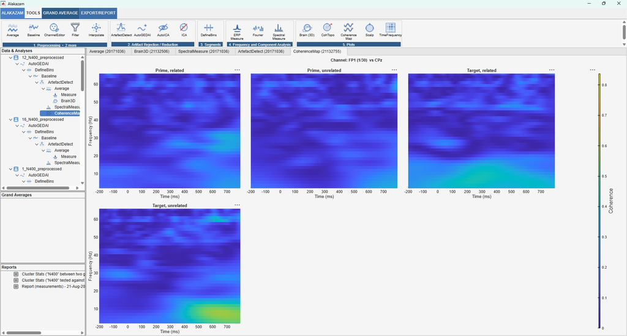

The reference is optional (not every recording has a photodiode), so power / SNR / phase-locking are always available and coherence is added when a reference is set. Results export to one long-format, R-compatible CSV via the Export/Report tab's **Spectral & Report** button ([`exportSpectralCSV.m`](https://github.com/markspan/Alakazam/blob/main/src/Reports/exportSpectralCSV.m)), which also renders a companion statistical report for it (see Statistical analysis): phase and phaselag are reported descriptively only where a test would not be statistically valid (see that section), power/amplitude/SNR/ITC/coherence get the full within-subjects/between-subjects/mixed treatment like any ERP measure.

A **`..._spectra.csv`** is written beside it, holding the evoked amplitude spectrum behind every one of those numbers, one row per dataset x bin x channel x frequency ([`exportSpectraCSV.m`](https://github.com/markspan/Alakazam/blob/main/src/Reports/exportSpectraCSV.m); thinned above 100 Hz, which for a tagging design is otherwise mostly noise floor). The report draws those spectra per bin with the tested frequencies marked on them, read from the same file as the values reported beside them, so a mark cannot drift from its number. That is what makes the failures peculiar to frequency tagging visible rather than merely tabulated: a tag that is simply absent still yields a power value and an SNR near 1, a response one bin away from where it was measured looks like a weak effect rather than a misplaced measurement, and an SNR computed against a neighbour band that is itself contaminated reads as an ordinary number.

The **time-resolved** coherence now reaches the report as well, as two companion files rather than one. `..._coherence_trace.csv` holds coherence against time at the tagged frequency for **every** channel, and the report draws it per condition: rise, plateau and fall are visible on it directly, so a measurement window that starts inside the fade-in or ends after the response has decayed is apparent rather than taken on trust. The tagged frequency is read from the exported map itself, as the frequency carrying most coherence in each condition, so it cannot drift from a number typed elsewhere. `..._coherence_map.csv` holds the full time by frequency plane for the few channels with the strongest response, drawn as the faceted heatmap a tagging paper prints; that split exists because the whole plane for a 64-channel montage runs to about 37 MB per recording, where the trace is about 1 MB. Neither carries a test: the inference in a tagging design is on the scalar coherence, which the sections above already handle.

Like any transformation, a whole tagging pipeline can be replayed across a study with Apply to All Raw Files or a saved template. The full reference is the [`SpectralMeasure.m`](https://github.com/markspan/Alakazam/blob/main/src/Transformations/SpectralMeasure/SpectralMeasure.m) header.

## Exporting the analysis as code

The Export/Report tab's **Export as Code** button (its own *Reproducibility* group, since the batch-export buttons write out results and this writes out the method) turns the whole workspace into a runnable MATLAB script: every root recording's processing chain, in order, with the options that were actually used, through to the grand averages. Each `DefineBins` bin script travels beside it as its own file. The result is a plain `.m` that can be read, edited, version-controlled, quoted in a methods section, and re-run without the app.

It is built from the **tree**, not from a scan of the cache directory: a cache outlives the workspaces that wrote it, and a script built from stale files would describe an analysis this workspace never performed.

Four things make the output worth keeping rather than merely correct:

- Recordings processed identically are emitted **once, as a loop**. Grouping is by exact equality of the chain, so a subject who genuinely differs keeps their own block instead of being silently given someone else's settings.
- Every step's options are **hoisted into named variables** in one block at the top, so the head of the script is the settings and the body is the pipeline.
- Each recording runs inside `try`/`catch`, with failures collected and reported at the end. A batch that dies on subject 3 of 40 and discards the other 37 is not a batch.
- `%%` sections, so the editor can fold and run them and the structure shows in the outline.

**It names the underlying library where naming it is faithful.** Most of Alakazam's pipeline is a thin wrapper over EEGLAB, FieldTrip or GEDAI, and a line reading `pop_resample(EEG, 250)` carries further than one reading `Resample(EEG, opts)`: it can be read by anyone in the field and run without this application. Four steps are written that way today:

| Step | Emitted as |
| --- | --- |
| `Resample` | `pop_resample` |
| `ReRef` | `pop_reref`, with the reference resolved from labels by a plain `find(ismember(...))` |
| `Interpolate` | `pop_interp`, the same way |
| `SelectData` | `pop_select`, when the selection is channels only |

Each carries whatever its transformation does *around* the library call, which is the part that is easy to get wrong: `Resample` re-derives the time axis in seconds and normalises `DataType`, `SelectData` restores the seconds axis only on continuous data and only when it actually selected something, and both `Interpolate` and `SelectData` keep their no-op guard for a stored channel the dataset does not have. Where the transformation refuses rather than no-ops, the emitted lines refuse too: `pop_reref` reads an empty reference as *average reference* and would apply one silently, so the emission asserts first.

The line is drawn wherever a native call would have to *re-derive* something. `Filter` designs its own windowed-sinc kernel (`firwsord`/`windows`/`firws`, applied by `firfilt`), and inlining that would copy the design logic into the script and diverge the day the transformation changed. A `SelectData` carrying a time, point or trial range converts units first (the dialog collects milliseconds on epoched data, `pop_select` always wants seconds). `AutoEyeICA` and `AutoGEDAI` are pipelines rather than calls. Those keep the transformation call and carry a comment naming the library function that actually does the work, so the script documents the method even where it cannot spell it natively.

That restraint is the point rather than a limitation. A re-implementation nothing checks is worse than an honest wrapper call, because it looks authoritative and can quietly disagree with the results it claims to reproduce. Every transformation the exporter is allowed to spell natively therefore has a case in [`NativeExportEquivalenceTest.m`](https://github.com/markspan/Alakazam/blob/main/tests/NativeExportEquivalenceTest.m) that runs both routes and compares **every field**, not just the samples: an earlier version compared the data alone and passed while the `Resample` emission left a time axis a factor of 1000 out. That file's own last test reads the emitter's source and fails if a native emission was added without a case.

Written by [`exportAnalysisScript.m`](https://github.com/markspan/Alakazam/blob/main/src/IO/exportAnalysisScript.m), with the native spellings in [`nativeTransformCall.m`](https://github.com/markspan/Alakazam/blob/main/src/IO/nativeTransformCall.m), and driven from [`onExportAnalysisScript.m`](https://github.com/markspan/Alakazam/blob/main/src/@Alakazam/onExportAnalysisScript.m).

## Using your own data

The preceding sections describe analyses performed on recordings referenced by a *workspace*. This section documents the procedure for directing Alakazam to user-supplied recordings, for specifying the experimental design, and for configuring the application's display preferences, independent of any single transformation.

### Starting with your own recordings

A workspace consists of three directories and a small quantity of persistent state.

- **Raw data directory**: the location of the source recordings. Every file present directly within this directory is registered as a root node in the Data & Analyses tree. Supported formats are `.set` (EEGLAB), `.vhdr`/`.eeg`/`.vmrk` (BrainVision), `.erp` (an ERPLAB erpset, imported as an already-averaged root node), and `.mat` (a previously saved Alakazam session).
- **Intermediate directory**: the cache in which the output of every transformation is stored, organised in a subdirectory per recording that mirrors the raw file's own name. This permits the analysis tree to be reconstructed in a later session without recomputation (see Architecture).
- **Exports directory**: the default destination for CSV and report exports.

On a fresh installation there is no workspace file yet. Rather than opening onto an empty tree and leaving you to work out why, Alakazam notices this and opens a **Welcome** dialog on that first run, which asks for the raw data directory. It is the same dialog as **Edit WorkSpace...** below, so the same control is used subsequently. The raw folder is left blank rather than prefilled with a placeholder path, and **OK** is refused until a folder has been chosen. **Cancel** leaves the tree empty.

Thereafter the repository's `DefaultWorkSpace.wksp` is loaded automatically by `startAlakazam` (see Installation). To analyse user-supplied recordings, this file may be edited directly: it is a JSON object with `RawDirectory`, `CacheDirectory`, and `ExportsDirectory` fields, in which the `~` character resolves to the user's home directory: or the three directories may be reassigned from within the application via **Edit WorkSpace...** (below). In either case, the raw directory is rescanned and the tree reconstructed as soon as the directories are changed.

### Editing the workspace

The Alakazam tab's **Workspace** group provides the following operations.

- **Open WorkSpace...**: loads a specified `.wksp` file, including its directories, previously recorded transformation parameters, and group/subject assignments.
- **Save WorkSpace...**: writes the current directories, the most recently used parameters of every transformation, and any group/subject assignments to a `.wksp` file, such that the session may be restored in full when reopened. No component of this state is persisted automatically; **Save WorkSpace** constitutes the sole point at which it is written to disk (see Settings, a distinct, machine-wide preference file).
- **Edit WorkSpace...**: modifies the Raw, Intermediate, and Exports directories directly, via a directory-browser control for each field, without requiring a `.wksp` file.
- **Clear WorkSpace**: deletes the entire Intermediate (cache) directory and rescans the raw directory from its initial state. This operation removes the results of every transformation for every subject, not a single selected subject; a confirmation prompt precedes execution, but the operation cannot be reversed once confirmed.
- **Clear Other**: retains a single subject's analysis branch (the selected root node, or the first such node if none is selected) and removes every other subject's branch, for use when regenerating the remaining subjects' pipelines from a revised template while preserving the one on which it was developed.

### Specifying the design

Every workspace is, by default, a within-subjects design: each bin or condition is assumed to have been measured for every subject. Specification of an alternative design, a between-subjects comparison, or the association of multiple recordings (e.g., session 1/2, pre/post) with a single individual, is performed through a single dialog, **Grouping...**, located in the Alakazam tab's **Design** group. The procedure and its statistical consequences are described in full in Groups: setting up a between-subjects or mixed design. As with the workspace's directories, group and subject assignments are retained only for the duration of the current session unless explicitly written to disk via **Save WorkSpace**.

### Settings

**Global...**, located in the Alakazam tab's **Settings** group, opens the application's preference dialog. These settings govern display behaviour uniformly, independent of the active workspace.

- **Graphics** tab: ERP-plot polarity (positive deflection oriented upward or downward), a shared versus per-electrode y-axis, the confidence-interval band and its width, whether trials in the epoch image are grouped by bin, the colour map applied to every signed, zero-centred plot (ERP image, ERSP power, scalp topography), and whether the Fourier power spectrum is smoothed prior to display.
- **Frequency bands** tab: the named frequency ranges (label, lower and upper bound, colour) shaded beneath the Fourier plot; bands may be added, modified, or removed here.

The epoch image, trials grouped by bin (Prime/Target x related/unrelated):

[figure not shown]

The Fourier plot, with a configured frequency band shaded beneath the spectrum:

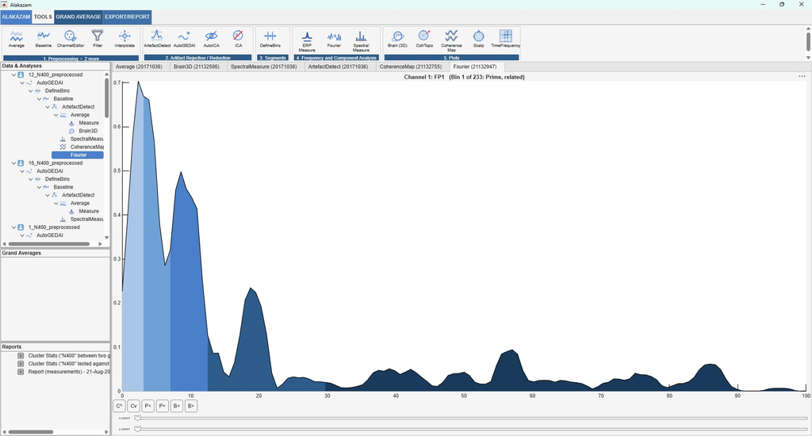

Selecting **Save** within this dialog writes the configuration to a machine-wide preference file immediately, independent of the active workspace and irrespective of whether **Save WorkSpace** has been invoked. No separate save operation is required for these settings.

## How-to walkthroughs

Three worked pipelines, plus a fourth that is a complete, reproducible run on real published data rather than a recipe (see below). Each is an ordinary chain of transformations, so once built on one recording it replays across a whole study in one click with **Apply to All Raw Files** (a branch's right-click menu) or a saved template. The marker codes below (`"S2?"`, `"201"`, ...) are placeholders: substitute the ones your recording actually used. Ready-made measurement windows live in [`presets/`](https://github.com/markspan/Alakazam/blob/main/src/Transformations/Measure/presets) (the Measure dialog's **Load...** button); the full measure reference is [`measure.md`](https://github.com/markspan/Alakazam/blob/main/src/Transformations/Measure/measure.md).

The examples lean on the [`DefineBins`](https://github.com/markspan/Alakazam/blob/main/src/Transformations/DefineBins) language, which is worth knowing a little of, because it is what makes each design precise:

- **`let name = ...`** names a code or relation once so bins stay readable.
- **Wildcards and sets**: `"S2?"` matches any `S2x` marker; `a|b` or `{a b}` is a set of alternatives.
- **Relations**: `next(code) within (lo,hi] ms` (also `prev`, `adjacent`, `any`) constrains a neighbouring event; the window is signed and gates reaction time.
- **`... rt within (lo,hi] ms`** keeps a match only if its RT is in range.
- **`... timelock <relation>`** re-centres the epoch on a neighbour (e.g. the response) instead of the anchor: this is how a bin defined on the *stimulus* becomes *response-locked* (used by the LRP below).
- **Combination bins** take coefficients: `bin 3 = 0.5 bin 2 - 0.5 bin 1`.

**How to do a P300 analysis (oddball)** (click to expand)**

### How to do a P300 analysis (oddball)

The P300 is a large centro-parietal positivity, 300 to 600 ms, to rare target stimuli. Stimulus-locked.

1. **Filter** the raw recording (`Filter`, e.g. 0.1 Hz high-pass, 30 Hz low-pass).
2. **DefineBins**, splitting rare targets from frequent standards and adding the oddball difference wave. Here the rare bin also requires the participant to have actually responded, in a plausible RT window, so misses and slow lapses are excluded; the epoch stays **stimulus-locked** (no `timelock`, the deliberate contrast with the LRP below):

   ```
   epoch [-200,800] ms
   let responded = next("201") within (200,1200] ms
   bin 1 "Rare"       : "S2?" and responded
   bin 2 "Frequent"   : "S1?"
   bin 3 "Rare-Freq"  = bin 1 - bin 2
   ```

   `"S2?"` is any rare-target marker and `"S1?"` any frequent one (wildcards); `responded` names "a button press 200 to 1200 ms after the stimulus".
3. **Baseline** to the pre-stimulus interval (-200 to 0 ms), then **ArtefactDetect** to reject bad trials.
4. **Average**.
5. **Measure**: Load the `p300` preset (Pz, 300 to 600 ms, mean amplitude), or the `erp_components_mean_amplitude` battery. Read the `Rare` bin for the P300 itself, and the `Rare-Freq` bin for the oddball effect.
6. **Grand Average** across subjects, then export for one long-format CSV and a companion statistical report (the **Export/Report** ribbon tab's **ERP & Report** button, see Statistical analysis). If subjects belong to different groups (e.g. patients vs. controls), assign them first with **Grouping...** (Alakazam tab, Design group) to get a between-subjects/mixed comparison instead of a within-subjects one.

**How to do an LRP analysis (response-locked)** (click to expand)**

### How to do an LRP analysis (response-locked)

The lateralised readiness potential is the motor-cortex difference between the hands, building up before the response. It is a **double subtraction**: contralateral minus ipsilateral, averaged over left- and right-hand responses. Response-locked.

1. **Filter** the raw recording.
2. **DefineBins**. This is the crux, and it shows off the language. Each bin is *defined on the imperative stimulus* (which holds the trial's condition), but `timelock`-ed onto the button press so the epoch is **response-locked** (time 0 = the press). Split by the hand actually used, then form the coefficiented combination bin for the double subtraction:

   ```
   epoch [-800,200] ms
   let leftPress  = next("201") within (150,1500] ms
   let rightPress = next("202") within (150,1500] ms
   bin 1 "Left-hand"  : "S1?" and leftPress   timelock leftPress
   bin 2 "Right-hand" : "S1?" and rightPress  timelock rightPress
   bin 3 "LRP"        = 0.5 bin 2 - 0.5 bin 1
   ```

   Reading it: `"S1?"` is any imperative stimulus (the condition the bin holds); `leftPress` / `rightPress` name the left (`"201"`) and right (`"202"`) button presses once, gated to a 150 to 1500 ms RT window so anticipations and misses drop out; `and leftPress` keeps only stimuli followed by that press; `timelock leftPress` then re-centres each epoch on the press even though the bin is anchored at the stimulus. `next(...)` picks the nearest following press, so as long as trials are seconds apart it is the trial's own response. Bins 1 and 2 therefore contain the left- and right-hand trials, response- locked; `bin 3` is the double subtraction.
3. **Average**.
4. **Measure**: define the motor difference as a derived channel in the **Derived channels** field, and measure it on the `LRP` bin:

   ```
   let LRP = C3 - C4
   ```

   with one window (Load the `lrp` preset as a starting point, then set its Channels to `LRP`): -100 to 0 ms, mean amplitude, channel `LRP`. Read the `LRP` bin (bin 3). This appends an `LRP` channel to the dataset, so it also shows on the ERP plot. (Why `0.5 bin 2 - 0.5 bin 1` on `C3 - C4` is exactly the LRP: on `C3 - C4`, a right-hand response gives contra minus ipsi and a left-hand response its negation, so half their difference is the mean over hands of contra minus ipsi.) LRP **amplitude** is straightforward this way; LRP **onset latency** wants a jackknife across subjects, which is not yet built in.

**How to do an MMN analysis (passive auditory oddball)** (click to expand)**

### How to do an MMN analysis (passive auditory oddball)

The mismatch negativity is a fronto-central negativity, 150 to 250 ms, seen in the deviant-minus-standard difference wave. Stimulus-locked, attention not required.

1. **Filter** the raw recording (a low-pass around 20 to 30 Hz is common for MMN).
2. **DefineBins**, forming the deviant-minus-standard difference wave (the MMN is defined on this difference, not the raw deviant). For a cleaner contrast, the control standard here is not just any standard but the one **immediately before each deviant**, via `adjacent`, which matches adaptation and serial position between the two bins. MMN is passive, so there is no response and no `timelock`:

   ```
   epoch [-100,400] ms
   let standard = "S1"
   let deviant  = "S2"
   bin 1 "Deviant"        : deviant
   bin 2 "Std before dev" : standard and adjacent(deviant)
   bin 3 "MMN"            = bin 1 - bin 2
   ```

   `adjacent(deviant)` is true when the event's immediately following event is a deviant, so `bin 2` collects exactly the standards that directly precede a deviant.
3. **Baseline** to the pre-stimulus interval (-100 to 0 ms), then **ArtefactDetect**.
4. **Average**.
5. **Measure**: Load the `mmn` preset (Fz, 150 to 250 ms, mean amplitude, negative), and read the `MMN` difference bin (bin 3) at Fz.
6. **Grand Average**, then export via the **Export/Report** tab's **ERP & Report** button. Since `MMN` is a difference bin measured as mean amplitude, the companion statistical report tests it against zero (see Statistical analysis), the natural way to ask whether the mismatch response is actually present.

**A worked example, start to finish: the ERP CORE N400 dataset** (click to expand)**

### A worked example, start to finish: the ERP CORE N400 dataset

Unlike the three recipes above, this one is a complete, reproducible run on real published data, using a template ([`N400.alztemplate`](https://github.com/markspan/Alakazam/blob/main/templates/N400.alztemplate)) that ships in the repository, ending in an actual rendered statistics report, not a generic recipe with placeholder marker codes.

**The data.** The ERP CORE N400 experiment (Kappenman, Farrens, Zhang, Stewart, & Luck, 2021, see References) is a semantic-priming paradigm: each trial shows a *prime* word followed by a *target* word, and the target is either semantically **related** to the prime (e.g. TABLE then CHAIR) or **unrelated** (e.g. RAKE then SPIDER). The participant presses one of two buttons on each trial to judge which. Luck's textbook chapter 2 walks through processing one participant; chapter 3 repeats it across "10 of the 40 participants in the actual study": the same 10-participant subset used here (`Data/Luck/ch3` in a local checkout: ten `<id>_N400_preprocessed.set` EEGLAB recordings, already filtered/referenced, ready to be epoched, cleaned and averaged). Get the data itself from the textbook's own exercise-data archive (doi.org/10.18115/D50056) or the full ERP CORE release (doi.org/10.18115/D5JW4R); it is not bundled with this repository. The textbook's own worked example measures the N400 at CPz (where it is typically largest) over roughly 200-600 ms; the template below measures a slightly narrower, nearby window (Cz, 300-500 ms) as its own choice, not a reproduction of the book's exact numbers.

**Building the template.** `N400.alztemplate` is six ordinary transformations chained together, in the order you would run them by hand the first time; saving that chain as a template (**Save Template...**) is what turns "the steps I just ran on subject 1" into "the recipe every subject gets". The order itself: denoise, then epoch/baseline, then reject, then average, is not arbitrary: artefact correction (a nonlinear operation) has to happen before artefact rejection and averaging for its own result to be meaningful, whereas the purely linear steps (filtering, re-referencing, baselining, averaging) commute freely, exactly the ordering rationale Luck lays out in [Order of processing steps](https://erpinfo.org/order-of-steps) (see References). `Filter`'s own choice of a zero-phase FIR windowed-sinc design, with the filter order and transition band picked automatically from the requested frequency and stopband attenuation rather than left for the analyst to guess, follows the practical guidance in Widmann, Schröger & Maess (2015). Built fresh from an imported raw recording, each step's own options dialog on the **Tools** tab would ask for:

1. **AutoGEDAI** (denoise). Its dialog has three groups of options: *Denoising*: **Strength** (`auto`/`auto+`/`auto-`, this template leaves it at `auto`: GEDAI's own SENSAI signal/artefact-subspace thresholding decides how aggressively to separate brain signal from noise, rather than a fixed cutoff), a **Leadfield matrix** (`precomputed`, matching channels to GEDAI's own bundled 10-5 template by label alone: `interpolated` would additionally need real 3-D electrode positions, not necessary here), and a **Low-cut frequency** of `0.4` Hz (GEDAI's own high-pass, separate from running a general-purpose `Filter` step first). *Bad epoch/ channel rejection*: both left off (`no`) here: ArtefactDetect, three steps later, is where this template does its rejection, explicitly and visibly, rather than silently inside the denoiser. *Performance*: **Use parallel processing**, left at `no` (only meaningful with a GPU present anyway). GEDAI is a separate, non-commercially-licensed EEGLAB plugin (Ros et al., 2025); the first run on a machine without it prompts to download it, with consent, before anything else happens.
2. **DefineBins** (epoch and label the trials). Two fields: an **epoch** window, `-200` to `800` ms around each matched event (so every trial's epoch spans 200 ms of pre-stimulus baseline material through 800 ms post-stimulus), and the bin **script** itself: imported here from the experiment's own bin descriptor (`BDF_N400.txt`, ERPLAB's original BDF format, one condition per event-code set) rather than typed by hand:

   ```
   bin 1 "Prime word, related to subsequent target word"     : 111|112
   bin 2 "Prime word, unrelated to subsequent target word"    : 121|122
   bin 3 "Target word, related to previous prime, followed
           by correct response"   : 211|212 and next(201) within [200,1500] ms
   bin 4 "Target word, unrelated to previous prime, followed
           by correct response"   : 221|222 and next(201) within [200,1500] ms
   bin 5 "N400" = bin 4 - bin 3
   ```

   Bins 1-2 are the prime words themselves (marker sets `111|112`/`121|122`), split by whether the *target* that follows them will be related or unrelated. Bins 3-4 are those target words, each additionally requiring `next(201) within [200,1500] ms`: the bin language's relation syntax for "a `201` (correct- response) marker follows within 200 to 1500 ms", so a missed or implausibly fast trial is excluded from the scored data rather than silently averaged in. `bin 5` is a **combination bin** (`bin 4 - bin 3`, no marker of its own): the classic N400 contrast, unrelated minus related targets, built once here so every later step (Average, Measure, the statistics report) can treat it exactly like any other condition.
3. **Baseline** (pre-stimulus correction). Two fields, **Start**/**Stop** in ms: `-100` to `-10`. Every channel's own mean over that interval, in every trial, is subtracted from the whole epoch: the ordinary ERP baseline correction, done once here on single-trial data (distinct from `Measure`'s own *optional*, later, per-window baseline, see step 6).
4. **ArtefactDetect** (reject bad trials). The dialog actually offers four detectors (Absolute threshold, Step function, Moving-window peak-to-peak, Sample-to-sample: ERPLAB's own set), any combination of them, and a choice of rejecting the whole epoch or just the offending channel when one trips. This template uses the simplest: **Absolute threshold**, **Minimum**/**Maximum** = `-100`/`100` µV, whole-epoch scope: any single sample outside ±100 µV, on any channel, rejects that trial's epoch entirely (the rejected data is set to `NaN`, which `Average` omits rather than treating as a real zero).
5. **Average**. No options beyond acknowledging the input (`Param: Init` here is just that acknowledgement, not a real setting): it produces one ERP per bin, over the trials that survived step 4, automatically including bin 5's own difference wave (computed from bins 3 and 4's *already-averaged* waveforms, not their raw trials, see Average above) once both of those have resolved.
6. **Measure** (turn the waveform into numbers). This is the step that decides what actually gets exported and tested, so it is worth knowing the full shape of what it can ask for, not just what this one template happens to use. Each row of its window table names a **measure type**: **Mean Amplitude** (the average of the waveform over the window: the default recommendation for most component analyses: unbiased by noise or window length, unlike a raw peak), **Peak** (the single most extreme sample's amplitude *and* latency, by **Polarity**), **Area** (a trapezoidal integral, `Signed`/`Rectified`/`Positive`/`Negative`, either over the whole window or a peak-locked band `Width` ms wide), and the two robust timing measures, **Fractional Peak Latency** and **Fractional Area Latency** (the time reaching a chosen **Fraction**, e.g. `0.5`, of the peak or of the window's cumulative area: the latter is the recommended onset/timing measure over raw peak latency). A **Local pts** setting (0 = the absolute extreme; N ≥ 1 = the most extreme *local* peak) guards the peak-based measures against a window-edge sample or a lone noise spike; an optional **Reference channel** locks Peak/band-Area latency to one channel so every other listed channel shares it instead of each drifting to its own local peak; **Channels** accepts several labels, blank for "every channel", and `{A B C}` to pool a region of interest into one NaN-tolerant mean; and every row can carry its own optional **Baseline (ms)** interval, independent of step 3's whole-epoch one.

   This template defines exactly **one** window: Label `N400`, Start/Stop `300`/`500` ms, Measure `Mean Amplitude`, Polarity `Negative`, Channels `Cz`: Width/Local pts/Fraction/Area mode/Baseline/Reference channel are all left blank, since none of them apply to Mean Amplitude (the dialog greys them out for exactly that reason; Polarity specifically is stored on the row but, per Mean Amplitude's own definition, plays no part in the computed number, it is carried over here from where this window started, the `n400` single-component preset in [`measure.md`](https://github.com/markspan/Alakazam/blob/main/src/Transformations/Measure/measure.md)'s own preset library, which records the component's usual negative-going direction as documentation even though this particular measure ignores it). Every bin gets this same 300-500 ms Cz mean, uniformly, including the `N400` combination bin from step 2: there is no separate "which bins to measure" setting.

Import each participant's raw recording, apply the template once (drag it onto the first imported dataset, or right-click -> **Apply Template...**), check the result, then right-click that same processed branch and choose **Apply to All Raw Files...** to replay the identical six steps over the other nine recordings in one action, rather than dragging the template onto each of the ten root nodes by hand. **Grand Average** across all ten, then the **Export/Report** tab's **ERP & Report** button writes the CSV and renders the companion Quarto report.

[figure not shown]

Ten of ten subjects contributed a value in every one of the four conditions, so a real render of this export produced:

| bin | *M* (µV) | *SD* | *n* |
| --- | --- | --- | --- |
| Prime, related | 0.178 | 1.647 | 10 |
| Prime, unrelated | 0.186 | 2.027 | 10 |
| Target, related | 3.563 | 2.247 | 10 |
| Target, unrelated | 0.804 | 1.763 | 10 |

The maximal linear mixed model (random intercept **and** slope per subject) did not converge to a non-singular fit with only 10 subjects x 4 conditions, so the report fell back to a random-intercept-only model, narrating that fallback rather than silently switching. That model still found a significant effect of bin, *F*(3.0, 27.0) = 19.95, *p* < .001, partial η<sup>2</sup> = .689, 95% CI [.494, 1.000] (marginal *R*<sup>2</sup> = .348). Holm-corrected model-based pairwise contrasts (`emmeans`) narrowed that omnibus effect down to exactly three significant pairs, all involving one condition: Prime,related - Target,related (*p* < .001), Prime,unrelated

- Target,related (*p* < .001), and Target,related - Target,unrelated (*p* < .001); every other pair, including Prime,related vs. Prime,unrelated, was not significant. A Friedman test on the same 10 complete-data subjects, run as a rank-based robustness check, agreed: χ<sup>2</sup>(3) = 18.12, *p* < .001.

**The question this answers, and what the numbers say.** Whether N400 mean amplitude at Cz differs across the four conditions, and it does, with a very large effect (partial η<sup>2</sup> = .689 is well past Cohen's "large" benchmark of .14; the wide CI reflects the small, 10-subject sample, not a weak effect). The pairwise table shows *why*: it is not that all four conditions differ, but that Target, related (M = 3.56 µV) stands apart from the other three, which do not differ from each other. Target, unrelated (M = 0.80 µV) is markedly less positive than Target, related in this 300-500 ms window, exactly the textbook N400 pattern (Kappenman et al., 2021; Kutas & Hillyard, 1980): a semantically unrelated target elicits a larger centro-parietal negativity than a related one, while the two prime conditions (which carry no semantic relationship to score yet) sit indistinguishably near zero, as expected. The `N400` combination bin's own vs-zero test is the direct, single-number version of the same finding: the priming effect itself (unrelated minus related) is reliably below zero across subjects, not just different-looking in an omnibus sense.

## References

Scientific/methodological:

- Luck, S. J. *Applied Event-Related Potential Data Analysis*. LibreTexts. socialsci.libretexts.org. DOI: 10.18115/D5QG92. Licensed CC BY 4.0. A practical, EEGLAB/ERPLAB-based reference for the preprocessing, averaging, and scoring steps that Alakazam's transformations implement. Its own worked N400 example, [`N400.alztemplate`](https://github.com/markspan/Alakazam/blob/main/templates/N400.alztemplate) ported to Alakazam, is the full worked example above.
- Pütz, C., Span, M., & Lorist, M. M. (2025). Protocol for designing, conducting, and analyzing event-related potentials in human participants. *STAR Protocols*, 6(2), 103835. DOI: 10.1016/j.xpro.2025.103835. A step-by-step protocol covering the same end-to-end workflow Alakazam is built around: designing an ERP task, recording and preprocessing the EEG (MATLAB, EEGLAB/FieldTrip), and exporting ERP measures for statistical analysis.
- Keil, A., Debener, S., Gratton, G., Junghöfer, M., Kappenman, E. S., Luck, S. J., Luu, P., Miller, G. A., & Yee, C. M. (2014). Committee report: Publication guidelines and recommendations for studies using electroencephalography and magnetoencephalography. *Psychophysiology*, 51(1), 1-21. DOI: 10.1111/psyp.12147. The field's current publication standards behind the Overview's own "established, reproducible ERP/EEG practice" framing above.
- Kappenman, E. S., Farrens, J. L., Zhang, W., Stewart, A. X., & Luck, S. J. (2021). ERP CORE: An open resource for human event-related potential research. *NeuroImage*, 225, 117465. DOI: 10.1016/j.neuroimage.2020.117465. The N400 experiment (and nine others) the worked example above is drawn from; data via doi.org/10.18115/D5JW4R.
- Kappenman, E. S., & Luck, S. J. (2016). Best practices for event-related potential research in clinical populations. *Biological Psychiatry: Cognitive Neuroscience and Neuroimaging*, 1(2), 110-115. DOI: 10.1016/j.bpsc.2015.11.007. The methodological considerations (component isolation, artefact rates, measurement choice, construct validity across groups) behind Groups' own patients-vs-controls framing above.
- Luck, S. J., Stewart, A. X., Simmons, A. M., & Kappenman, E. S. (2021). Standardized measurement error: A universal metric of data quality for averaged event-related potentials. *Psychophysiology*, 58(6), e13793. DOI: 10.1111/psyp.13793. The SME reported by `Average` (whole-epoch) and by the Data quality report (per measurement window, analytic for mean amplitude and bootstrapped for the non-linear scores).
- Clayson, P. E., & Miller, G. A. (2017). ERP Reliability Analysis (ERA) Toolbox: An open-source toolbox for analyzing the reliability of event-related brain potentials. *International Journal of Psychophysiology*, 111, 68-79. DOI: 10.1016/j.ijpsycho.2016.10.012. The generalizability-theory account of ERP dependability, and of how many trials a given component needs for a target reliability: the fuller answer the Data quality report's precision-against-trial-count figure approximates with SME and a 1/sqrt(*n*) curve.
- Mathôt, S., & Vilotijević, A. (2023). Methods in cognitive pupillometry: Design, preprocessing, and statistical analysis. *Behavior Research Methods*, 55(6), 3055-3077. DOI: 10.3758/s13428-022-01957-7. The data-quality assessment the Data quality report is adapted from, including its central argument that even loss across conditions matters more than total loss, and its practice of reporting rather than silently excluding.
- Kutas, M., & Hillyard, S. A. (1980). Reading senseless sentences: Brain potentials reflect semantic incongruity. *Science*, 207(4427), 203-205. DOI: 10.1126/science.7350657. The original discovery of the N400, the component the worked example above measures.
- Lopez-Calderon, J., & Luck, S. J. (2014). ERPLAB: an open-source toolbox for the analysis of event-related potentials. *Frontiers in Human Neuroscience*, 8, 213. erpinfo.org/erplab. The methodological model for `DefineBins` (event-to-bin assignment, replacing EVENTLIST + BINLISTER), `Average`'s contrast-bin handling, and `GrandAverage`'s weighted grand-average option; not a runtime dependency, ERPLAB itself is not called.
- Luck, S. J. Order of processing steps (excerpted from *An Introduction to the Event-Related Potential Technique*, 2nd ed., 2014). erpinfo.org/order-of-steps. The linear-vs-nonlinear-operations rationale behind the fixed step order (denoise/correct, then epoch and baseline, then reject, then average) every worked pipeline in this README, and `N400.alztemplate` itself, follows.
- Widmann, A., Schröger, E., & Maess, B. (2015). Digital filter design for electrophysiological data: a practical approach. *Journal of Neuroscience Methods*, 250, 34-46. DOI: 10.1016/j.jneumeth.2014.08.002. The practical rationale behind `Filter`'s own zero-phase FIR windowed-sinc design and its automatic choice of filter order and transition band from just a frequency and a stopband attenuation.
- Toffanin, P., de Jong, R., Johnson, A., & Martens, S. (2009). Using frequency tagging to quantify attentional deployment in a visual divided attention task. *International Journal of Psychophysiology*, 72(3), 289-298. DOI: 10.1016/j.ijpsycho.2009.01.006. The amplitude-based SSVEP read-out `SpectralMeasure` implements (power / SNR at the tagging frequency, modulated by attention).
- Dimigen, O., Badea, I., Simon, I., & Span, M. M. (2025). Rapid Invisible Frequency Tagging (RIFT) with a consumer monitor: A proof-of-concept. *bioRxiv*. DOI: 10.1101/2025.08.14.670287. The cross-coherence read-out `SpectralMeasure` implements: magnitude-squared coherence between a photodiode and each EEG channel, from trial-wise cross- spectra normalised by the trial-averaged autospectra.
- Ros, T., et al. (2025). GEDAI: generalized eigenvalue decomposition for automated EEG artefact removal. github.com/neurotuning/GEDAI-master. Used by the `AutoGEDAI` transformation.
- Pion-Tonachini, L., Kreutz-Delgado, K., & Makeig, S. (2019). ICLabel: An automated electroencephalographic independent component classifier, dataset, and website. *NeuroImage*, 198, 181-197. Used by `AutoEyeICA` to classify and remove eye components.
- Hyvärinen, A., & Oja, E. (2000). Independent component analysis: algorithms and applications. *Neural Networks*, 13(4-5), 411-430. FastICA, [research.ics.aalto.fi/ica/fastica](https://research.ics.aalto.fi/ica/fastica/). Used by `AutoEyeICA` when installed (falls back to `pop_runica`'s own default algorithm otherwise).
- Frömer, R., Maier, M., & Abdel Rahman, R. (2018). Group-level EEG-processing pipeline for flexible single trial-based analyses including linear mixed models. *Frontiers in Neuroscience*, 12, 48. DOI: 10.3389/fnins.2018.00048. The case for fitting ERP measures to individual trials rather than to per-subject averages, and the pipeline shape that makes it practical: the argument behind Single-trial models and the `..._trials.csv` export that feeds them.
- Volpert-Esmond, H. I., Page-Gould, E., & Bartholow, B. D. (2021). Using multilevel models for the analysis of event-related potentials. *International Journal of Psychophysiology*, 162, 145-156. DOI: 10.1016/j.ijpsycho.2021.02.006. Why unequal trial counts and within-subject variance are handled properly by a multilevel model and thrown away by averaging first, and why trial order belongs in the model: the reasoning behind the single-trial report's `value ~ bin + trial_c + (1 + bin | person_id)`.
- Barr, D. J., Levy, R., Scheepers, C., & Tily, H. J. (2013). Random effects structure for confirmatory hypothesis testing: Keep it maximal. *Journal of Memory and Language*, 68(3), 255-278. DOI: 10.1016/j.jml.2012.11.001. The argument for the maximal random-effects structure the design justifies, which is where the single-trial model starts before any reduction.
- Bates, D., Kliegl, R., Vasishth, S., & Baayen, H. (2015). Parsimonious mixed models. [arXiv:1506.04967](https://arxiv.org/abs/1506.04967). What to drop first when the maximal model will not converge: the correlation between random terms before the random slope itself, which is the reduction order Single-trial models follows and reports.
- Maris, E., & Oostenveld, R. (2007). Nonparametric statistical testing of EEG- and MEG-data. *Journal of Neuroscience Methods*, 164(1), 177-190. DOI: 10.1016/j.jneumeth.2007.03.024. The cluster-based permutation method **Cluster Test...** implements (see Cluster statistics).
- Groppe, D. M., Urbach, T. P., & Kutas, M. (2011). Mass univariate analysis of event-related brain potentials/fields I: A critical tutorial review. *Psychophysiology*, 48(12), 1711-1725. DOI: 10.1111/j.1469-8986.2011.01273.x. A tutorial survey of the multiple-comparisons problem cluster-based permutation testing addresses, and the alternative corrections available for it.
- Smith, S. M., & Nichols, T. E. (2009). Threshold-free cluster enhancement: addressing problems of smoothing, threshold dependence and localisation in cluster inference. *NeuroImage*, 44(1), 83-98. DOI: 10.1016/j.neuroimage.2008.03.061. TFCE, **Cluster Test...**'s default correction method (see Cluster statistics).
- Oostenveld, R., Fries, P., Maris, E., & Schoffelen, J.-M. (2011). FieldTrip: open source software for advanced analysis of MEG, EEG, and invasive electrophysiological data. *Computational Intelligence and Neuroscience*, 2011, 156869. DOI: 10.1155/2011/156869. [fieldtriptoolbox.org](https://www.fieldtriptoolbox.org/). The template head model, electrode positions, and cortical-sheet source model `Brain3D`'s Source-estimate mode builds its minimum-norm inverse on; an optional dependency, not bundled (see 3D brain view).
- Dale, A. M., Liu, A. K., Fischl, B. R., Buckner, R. L., Belliveau, J. W., Lewine, J. D., & Halgren, E. (2000). Dynamic statistical parametric mapping: combining fMRI and MEG for high-resolution imaging of cortical activity. *Neuron*, 26(1), 55-67. DOI: 10.1016/S0896-6273(00)81138-1. The dSPM noise-normalization `Brain3D`'s Source-estimate mode applies to its minimum-norm inverse (see 3D brain view).
- Pascual-Marqui, R. D. (2002). Standardized low-resolution brain electromagnetic tomography (sLORETA): technical details. *Methods and Findings in Experimental and Clinical Pharmacology*, 24 Suppl D, 5-12. `Brain3D`'s sLORETA source-estimate mode, computed via FieldTrip's `ft_inverse_sloreta` (see 3D brain view).
- Pascual-Marqui, R. D. (2007). Discrete, 3D distributed, linear imaging methods of electric neuronal activity. Part 1: exact, zero error localization. *arXiv*:0710.3341. arxiv.org/abs/0710.3341. `Brain3D`'s eLORETA source-estimate mode, computed via FieldTrip's `ft_inverse_eloreta` (see 3D brain view).
- Hämäläinen, M. S., & Ilmoniemi, R. J. (1994). Interpreting magnetic fields of the brain: minimum norm estimates. *Medical & Biological Engineering & Computing*, 32(1), 35-42. DOI: 10.1007/BF02512476. The distributed minimum-norm formulation every inverse in Alakazam builds on, and the reason the source stage estimates an amplitude at fixed positions rather than locating generators (see What the source estimate is, and is not).
- Baillet, S., Mosher, J. C., & Leahy, R. M. (2001). Electromagnetic brain mapping. *IEEE Signal Processing Magazine*, 18(6), 14-30. DOI: 10.1109/79.962275. The standard treatment of the EEG/MEG inverse problem as ill-posed, and of the role a prior plays in selecting one solution from infinitely many.
- Grech, R., Cassar, T., Muscat, J., Camilleri, K. P., Fabri, S. G., Zervakis, M., Xanthopoulos, P., Sakkalis, V., & Vanrumste, B. (2008). Review on solving the inverse problem in EEG source analysis. *Journal of NeuroEngineering and Rehabilitation*, 5, 25. DOI: 10.1186/1743-0003-5-25. A survey of the inverse methods and their assumptions, covering both the dipolar and the distributed families.
- Michel, C. M., & Brunet, D. (2019). EEG source imaging: a practical review of the analysis steps. *Frontiers in Neurology*, 10, 325. DOI: 10.3389/fneur.2019.00325. A current, practical account of the whole source-imaging chain, including the distinction between dipole fitting and distributed imaging that the section above draws on.
- Hauk, O., Wakeman, D. G., & Henson, R. (2011). Comparison of noise-normalized minimum norm estimates for MEG analysis using multiple resolution metrics. *NeuroImage*, 54(3), 1966-1974. DOI: 10.1016/j.neuroimage.2010.09.053. Point-spread and cross-talk functions for MNE, dSPM and sLORETA specifically, which is the basis for treating a vertex estimate as a mixture over a neighbourhood rather than a measurement at a point.
- Hauk, O., Stenroos, M., & Treder, M. S. (2022). Towards an objective evaluation of EEG/MEG source estimation methods: the linear approach. *NeuroImage*, 255, 119177. DOI: 10.1016/j.neuroimage.2022.119177. The current reference for evaluating linear inverse operators through the resolution matrix, and for what such operators can and cannot resolve.
- Akalin Acar, Z., & Makeig, S. (2013). Effects of forward model errors on EEG source localization. *Brain Topography*, 26(3), 378-396. DOI: 10.1007/s10548-012-0274-6. Quantifies the localisation error contributed by head-model and electrode position inaccuracies, which is the error this pipeline's template anatomy and template electrodes incur.
- Pernet, C. R., Garrido, M. I., Gramfort, A., Maurits, N., Michel, C. M., Pang, E., Salmelin, R., Schoffelen, J. M., Valdes-Sosa, P. A., & Puce, A. (2020). Issues and recommendations from the OHBM COBIDAS MEEG committee for reproducible EEG and MEG research. *Nature Neuroscience*, 23(12), 1473-1483. DOI: 10.1038/s41593-020-00709-0. The reporting checklist the source cluster report is written against, and the source of its forward-model, regularisation and software-version sections.
- Sassenhagen, J., & Draschkow, D. (2019). Cluster-based permutation tests of MEG/EEG data do not establish significance of effect latency or location. *Psychophysiology*, 56(6), e13335. DOI: 10.1111/psyp.13335. The specific misreading both cluster reports open by warning against: a cluster establishes that an effect exists, not where or when it begins and ends.
- Delorme, A., & Makeig, S. (2004). EEGLAB: an open source toolbox for analysis of single-trial EEG dynamics. *Journal of Neuroscience Methods*, 134(1), 9-21. [sccn.ucsd.edu/eeglab](https://sccn.ucsd.edu/eeglab/index.php). The data structure and plugin ecosystem (including the bva-io BrainVision import plugin and ICLabel above) Alakazam is built on.
- BrainVision Analyzer, the commercial analyser whose interaction model inspired Alakazam. [brainproducts.com](https://www.brainproducts.com/promo_analyzer2.php).

Software toolkits (see [`dependencies.md`](https://github.com/markspan/Alakazam/blob/main/dependencies.md) for the complete, versioned list):

- MATLAB Toolstrip / ToolGroup demo by R. Chen. [undocumentedmatlab.com](http://undocumentedmatlab.com/articles/matlab-toolstrip-part-2-toolgroup-app). Historical: the app shell this originally adapted has since been replaced by a single `uifigure` with a custom `uihtml` ribbon (see Architecture and [`migration.md`](https://github.com/markspan/Alakazam/blob/main/migration.md)); kept here as a credit to the original adapted code, not a description of the current UI.

## Repository

Source, issues, and contributions: github.com/markspan/Alakazam. Alakazam is a work in progress and contributions are welcome.

## License

See LICENSE (GPL).